Středa 9:15

Tým B

Členové: David Brablc, Vojtěch Kučík, Lukáš Kočí, Lukas Janetschek

# Rain prediction in Australia - classification

# Introduction

### 1. Describe the business value of addressing this problem with machine learning.

The ability to predict rain for tomorrow based on the weather observations the day before would bring significant business value in several ways:

- Agriculture Planning and Optimization: Accurate weather predictions can help farmers make informed decisions about planting, irrigating, and harvesting crops, leading to more efficient use of resources and potentially higher yields.
- Water Resource Management: By forecasting rain, water authorities can better manage water supply for cities and rural areas, optimizing the storage and distribution of water resources.
- Transportation and Logistics: Weather predictions are crucial for air travel, shipping, and road transport, affecting scheduling and routing decisions. Accurate forecasts can minimize weather-related delays and improve safety.
- Disaster Preparedness and Response: Early warnings about extreme weather conditions can mitigate the impact of natural disasters, allowing for timely evacuations and preparations, thus saving lives and reducing economic losses.

### 2. Provide the link to the source of the data.

Link: https://www.kaggle.com/datasets/jsphyg/weather-dataset-rattle-package?resource=download

### 3. Describe chosen customization: target attribute, an instance of interest, attribute of interest, cost matrix.

- Target Attribute: The target attribute for our classification and clustering problem is RainTomorrow. This attribute indicates whether it rained the next day ("Yes" or "No"), which is the outcome we aim to predict using other features in the dataset.
- Instance of interest: We will choose the instance of interest randomly

```python
import pandas as pd
import numpy as np
import seaborn as sns
import matplotlib.pyplot as plt
from sklearn.preprocessing import LabelEncoder
from sklearn.model_selection import train_test_split
from sklearn.ensemble import RandomForestRegressor, RandomForestClassifier
from sklearn.tree import DecisionTreeClassifier, plot_tree
from sklearn.model_selection import GridSearchCV, cross_val_score
from sklearn.metrics import accuracy_score, f1_score, auc, roc_curve, confusion_matrix, classification_report, silhouette_score, rand_score
from sklearn.naive_bayes import GaussianNB
from sklearn.cluster import AgglomerativeClustering, KMeans
from scipy.cluster.hierarchy import dendrogram, linkage
from sklearn.utils import resample
import warnings
from yellowbrick.cluster import KElbowVisualizer
from sklearn.feature_selection import VarianceThreshold
warnings.filterwarnings("ignore")
plt.rcParams['font.family'] = 'DejaVu Sans'
```

```python
rain_df = pd.read_csv('weatherAUS.csv')
rain_df
```

|  | Date | Location | MinTemp | MaxTemp | Rainfall | Evaporation | Sunshine | WindGustDir | WindGustSpeed | WindDir9am | ... | Humidity9am | Humidity3pm | Pressure9am | Pressure3pm | Cloud9am | Cloud3pm | Temp9am | Temp3pm | RainToday | RainTomorrow |
| --- | --- | --- | --- | --- | --- | --- | --- | --- | --- | --- | --- | --- | --- | --- | --- | --- | --- | --- | --- | --- | --- |
| 0 | 2008-12-01 | Albury | 13.4 | 22.9 | 0.6 | NaN | NaN | W | 44.0 | W | ... | 71.0 | 22.0 | 1007.7 | 1007.1 | 8.0 | NaN | 16.9 | 21.8 | No | No |
| 1 | 2008-12-02 | Albury | 7.4 | 25.1 | 0.0 | NaN | NaN | WNW | 44.0 | NNW | ... | 44.0 | 25.0 | 1010.6 | 1007.8 | NaN | NaN | 17.2 | 24.3 | No | No |
| 2 | 2008-12-03 | Albury | 12.9 | 25.7 | 0.0 | NaN | NaN | WSW | 46.0 | W | ... | 38.0 | 30.0 | 1007.6 | 1008.7 | NaN | 2.0 | 21.0 | 23.2 | No | No |
| 3 | 2008-12-04 | Albury | 9.2 | 28.0 | 0.0 | NaN | NaN | NE | 24.0 | SE | ... | 45.0 | 16.0 | 1017.6 | 1012.8 | NaN | NaN | 18.1 | 26.5 | No | No |
| 4 | 2008-12-05 | Albury | 17.5 | 32.3 | 1.0 | NaN | NaN | W | 41.0 | ENE | ... | 82.0 | 33.0 | 1010.8 | 1006.0 | 7.0 | 8.0 | 17.8 | 29.7 | No | No |
| ... | ... | ... | ... | ... | ... | ... | ... | ... | ... | ... | ... | ... | ... | ... | ... | ... | ... | ... | ... | ... | ... |
| 145455 | 2017-06-21 | Uluru | 2.8 | 23.4 | 0.0 | NaN | NaN | E | 31.0 | SE | ... | 51.0 | 24.0 | 1024.6 | 1020.3 | NaN | NaN | 10.1 | 22.4 | No | No |
| 145456 | 2017-06-22 | Uluru | 3.6 | 25.3 | 0.0 | NaN | NaN | NNW | 22.0 | SE | ... | 56.0 | 21.0 | 1023.5 | 1019.1 | NaN | NaN | 10.9 | 24.5 | No | No |
| 145457 | 2017-06-23 | Uluru | 5.4 | 26.9 | 0.0 | NaN | NaN | N | 37.0 | SE | ... | 53.0 | 24.0 | 1021.0 | 1016.8 | NaN | NaN | 12.5 | 26.1 | No | No |
| 145458 | 2017-06-24 | Uluru | 7.8 | 27.0 | 0.0 | NaN | NaN | SE | 28.0 | SSE | ... | 51.0 | 24.0 | 1019.4 | 1016.5 | 3.0 | 2.0 | 15.1 | 26.0 | No | No |
| 145459 | 2017-06-25 | Uluru | 14.9 | NaN | 0.0 | NaN | NaN | NaN | NaN | ESE | ... | 62.0 | 36.0 | 1020.2 | 1017.9 | 8.0 | 8.0 | 15.0 | 20.9 | No | NaN |

145460 rows × 23 columns

```python
np.random.seed(42)
random_index = np.random.randint(0, len(rain_df))

# Display the selected instance
selected_instance = rain_df.iloc[random_index]
selected_instance_info = selected_instance.to_dict()

print('index number: {}'.format(random_index))
selected_instance
```

```
index number: 121958
```

```
Date             2012-03-12
Location              Perth
MinTemp                15.8
MaxTemp                40.6
Rainfall                0.0
Evaporation             9.2
Sunshine               11.3
WindGustDir             WSW
WindGustSpeed          31.0
WindDir9am               NE
WindDir3pm              WSW
WindSpeed9am            9.0
WindSpeed3pm           13.0
Humidity9am            28.0
Humidity3pm            28.0
Pressure9am          1008.0
Pressure3pm          1005.1
Cloud9am                2.0
Cloud3pm                2.0
Temp9am                30.1
Temp3pm                33.9
RainToday                No
RainTomorrow             No
Name: 121958, dtype: object
```

- Attribute of Interest: For this instance, the "Humidity3pm" is 28%, it is the amount of moisture in the air compared to what the air can "hold" at that temperature. Higher humidity can be associated with increased cloud cover and the likelihood of precipitation, while lower humidity might be associated with clearer skies and drier conditions.
- Cost Matrix:

False Positive (FP) cost: 50 False Negative (FN) cost: 100 True Positive (TP) cost: 0 True Negative (TN) cost: 0

This cost matrix prioritizes minimizing the more severe consequences of false negatives (not predicting rain when it occurs) over the less critical false positives (predicting rain when it doesn't occur), which aligns with a cautious approach to weather forecasting where the cost of unpreparedness outweighs the inconvenience of unnecessary precautions.

```python
cost_matrix = {
    'Actual Positive': {'Predicted Positive': 0, 'Predicted Negative': 100},
    'Actual Negative': {'Predicted Positive': 50, 'Predicted Negative': 0}
}

cost_df = pd.DataFrame(cost_matrix, index=['Predicted Positive', 'Predicted Negative'])

assigned_costs = [0, 50, 100, 0] #[tp, fp, fn, tn]

# Display the cost matrix

print(f"Assigned costs array: {assigned_costs}")
cost_df
```

```
Assigned costs array: [0, 50, 100, 0]
```

|  | Actual Positive | Actual Negative |
| --- | --- | --- |
| Predicted Positive | 0 | 50 |
| Predicted Negative | 100 | 0 |

# 1) Data exploration

Show a histogram (or a table with value frequencies) for the target variable and for selected other variables 2. Show a scatterplot (correlation plot) showing the relation between selected predictors and the target variable 3. Interpret the results

```python
rain_df.head()
```

|  | Date | Location | MinTemp | MaxTemp | Rainfall | Evaporation | Sunshine | WindGustDir | WindGustSpeed | WindDir9am | ... | Humidity9am | Humidity3pm | Pressure9am | Pressure3pm | Cloud9am | Cloud3pm | Temp9am | Temp3pm | RainToday | RainTomorrow |
| --- | --- | --- | --- | --- | --- | --- | --- | --- | --- | --- | --- | --- | --- | --- | --- | --- | --- | --- | --- | --- | --- |
| 0 | 2008-12-01 | Albury | 13.4 | 22.9 | 0.6 | NaN | NaN | W | 44.0 | W | ... | 71.0 | 22.0 | 1007.7 | 1007.1 | 8.0 | NaN | 16.9 | 21.8 | No | No |
| 1 | 2008-12-02 | Albury | 7.4 | 25.1 | 0.0 | NaN | NaN | WNW | 44.0 | NNW | ... | 44.0 | 25.0 | 1010.6 | 1007.8 | NaN | NaN | 17.2 | 24.3 | No | No |
| 2 | 2008-12-03 | Albury | 12.9 | 25.7 | 0.0 | NaN | NaN | WSW | 46.0 | W | ... | 38.0 | 30.0 | 1007.6 | 1008.7 | NaN | 2.0 | 21.0 | 23.2 | No | No |
| 3 | 2008-12-04 | Albury | 9.2 | 28.0 | 0.0 | NaN | NaN | NE | 24.0 | SE | ... | 45.0 | 16.0 | 1017.6 | 1012.8 | NaN | NaN | 18.1 | 26.5 | No | No |
| 4 | 2008-12-05 | Albury | 17.5 | 32.3 | 1.0 | NaN | NaN | W | 41.0 | ENE | ... | 82.0 | 33.0 | 1010.8 | 1006.0 | 7.0 | 8.0 | 17.8 | 29.7 | No | No |

5 rows × 23 columns

We can look at all the columns that were provided in this dataset:

```python
rain_df.columns
```

```
Index(['Date', 'Location', 'MinTemp', 'MaxTemp', 'Rainfall', 'Evaporation',
       'Sunshine', 'WindGustDir', 'WindGustSpeed', 'WindDir9am', 'WindDir3pm',
       'WindSpeed9am', 'WindSpeed3pm', 'Humidity9am', 'Humidity3pm',
       'Pressure9am', 'Pressure3pm', 'Cloud9am', 'Cloud3pm', 'Temp9am',
       'Temp3pm', 'RainToday', 'RainTomorrow'],
      dtype='object')
```

```python
rain_df.index
```

```
RangeIndex(start=0, stop=145460, step=1)
```

## Exploring value frequencies

### Target value frequency

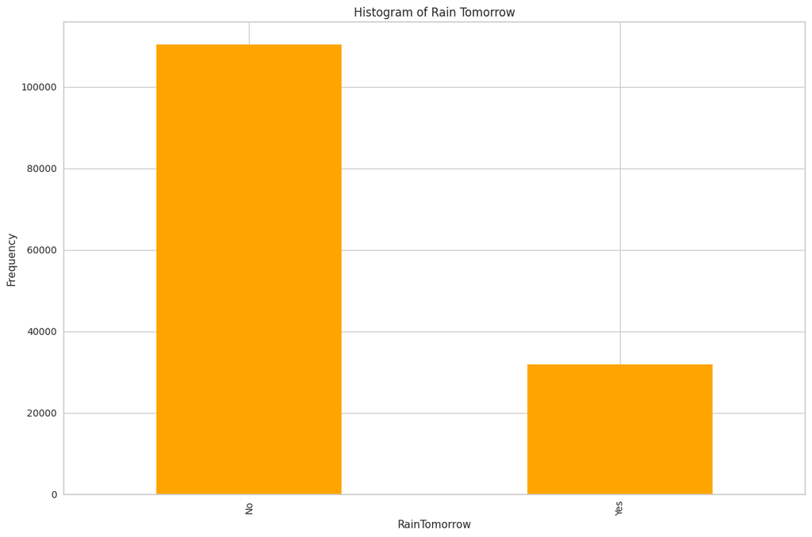

```python
plt.figure(figsize=(12, 8))

rain_df['RainTomorrow'].value_counts().plot(kind='bar', color='orange')
plt.title('Histogram of Rain Tomorrow')
plt.xlabel('RainTomorrow')
plt.ylabel('Frequency')

plt.tight_layout()
plt.show()
```

The graph states that there were significantly more days that were not followed by rain than the opposite. The NO category had a much higher frequency than the YES category.

### Frequency of chosen indicators

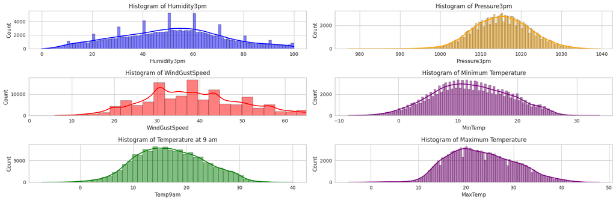

```python
# Plotting histograms for 'Humidity3pm', 'Pressure3pm', and 'WindGustSpeed'
fig, axs = plt.subplots(3, 2, figsize=(18, 6))

sns.histplot(data=rain_df, x='Humidity3pm', kde=True, ax=axs[0,0], color='blue')
axs[0,0].set_title('Histogram of Humidity3pm')

sns.histplot(data=rain_df, x='Pressure3pm', kde=True, ax=axs[0,1], color='orange')
axs[0,1].set_title('Histogram of Pressure3pm')

sns.histplot(data=rain_df, x='WindGustSpeed', bins=50, kde=True, ax=axs[1,0], color='red')
axs[1,0].set_title('Histogram of WindGustSpeed')
axs[1,0].set_xlim(0, rain_df['WindGustSpeed'].quantile(0.95))  # Limiting to 95th percentile for better visualization

sns.histplot(data=rain_df, x='MinTemp', kde=True, ax=axs[1,1], color='purple')
axs[1,1].set_title('Histogram of Minimum Temperature')

sns.histplot(data=rain_df, x='Temp9am',bins=50, kde=True, ax=axs[2,0], color='green')
axs[2,0].set_title('Histogram of Temperature at 9 am')

sns.histplot(data=rain_df, x='MaxTemp', kde=True, ax=axs[2,1], color='purple')
axs[2,1].set_title('Histogram of Maximum Temperature')


plt.tight_layout()
plt.show()
```

Humidity3pm: The distribution of humidity at 3 pm shows a wide range, with a slight skew towards higher humidity levels. This suggests that there are more instances of higher humidity in the dataset, which could be relevant to the occurrence of rain.

Pressure3pm: Atmospheric pressure at 3 pm appears to have a somewhat normal distribution with a central peak, indicating that most days have pressure values around this central range. Variations from this range might be indicative of weather changes, including the potential for rain.

WindGustSpeed: The distribution of wind gust speed is right-skewed, indicating that lower wind speeds are more common, but there are days with significantly higher wind speeds. This might correlate with weather systems that bring rain.

Temp9am: The distribution of temperature at 9 am has a slight skew to the left, where the the most values are between 10 to 20 degrees celsius.

The MaxTemp and MinTemp show some differences between each other. The histogram of minimum temperature shows a distribution with a slight left skew, indicating colder days are less common, while the maximum temperature has a slight right skew, suggesting hotter days are less frequent, with both distributions being roughly bell-shaped and centered around their respective middle ranges.

We can also look at the top 10 locations with the highest number of observations to see if it has rained there similarly.

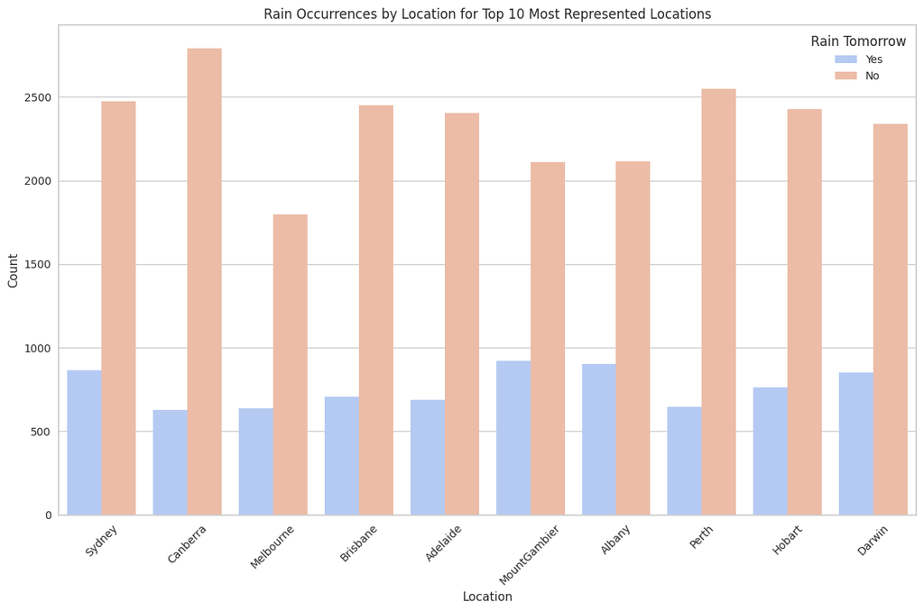

```python
# Find the top 10 locations with the highest number of observations
top_locations = rain_df['Location'].value_counts().head(10).index

# Filter the dataset for these top locations
data_top_locations = rain_df[rain_df['Location'].isin(top_locations)]

# Create a count plot
plt.figure(figsize=(12, 8))
sns.countplot(data=data_top_locations, x='Location', hue='RainTomorrow', palette='coolwarm')
plt.title('Rain Occurrences by Location for Top 10 Most Represented Locations')
plt.xticks(rotation=45)
plt.xlabel('Location')
plt.ylabel('Count')
plt.legend(title='Rain Tomorrow', loc='upper right')
plt.tight_layout()
plt.show()
```

This visualization allows us to see how the frequency of rain occurrences varies across different geographical locations.

## Relations between predictors and target variable

We will create scatter plots hoping they will show us the relation between selected predictors and the target variable.

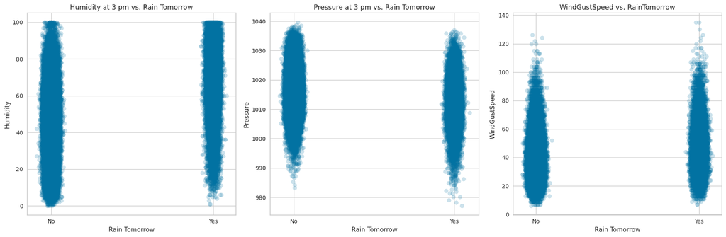

```python
def jitter_plot(x, y, jitter_amount=0.02):
    plt.xticks([0, 1], ['No', 'Yes'])
    x_jittered = x + np.random.normal(0, jitter_amount, size=len(x))
    plt.scatter(x_jittered, y, alpha=0.2)


data_clean = rain_df.dropna(subset=['MaxTemp', 'Humidity3pm', 'Pressure3pm', 'RainTomorrow'])
data_clean['RainTomorrow'] = rain_df['RainTomorrow'].map({'No': 0, 'Yes': 1})

plt.figure(figsize=(18, 6))



# Humidity3pm vs. RainTomorrow
plt.subplot(1, 3, 1)
jitter_plot(data_clean['RainTomorrow'], data_clean['Humidity3pm'])
plt.title('Humidity at 3 pm vs. Rain Tomorrow')
plt.xlabel('Rain Tomorrow')
plt.ylabel('Humidity')

# Pressure3pm vs. RainTomorrow
plt.subplot(1, 3, 2)
jitter_plot(data_clean['RainTomorrow'], data_clean['Pressure3pm'])
plt.title('Pressure at 3 pm vs. Rain Tomorrow')
plt.xlabel('Rain Tomorrow')
plt.ylabel('Pressure')

plt.subplot(1, 3, 3)
jitter_plot(data_clean['RainTomorrow'], data_clean['WindGustSpeed'])
plt.title('WindGustSpeed vs. RainTomorrow')
plt.xlabel('Rain Tomorrow')
plt.ylabel('WindGustSpeed')
plt.tight_layout()
plt.show()
```

The scatter plots show us that there are some differences between the values of predictors depending on the target attribute, although they are not very easy to read, therefore we will use boxplots instead to examine the relationships.

Other weather actors commonly associated with precipitation are humidity, pressure and windspeed:

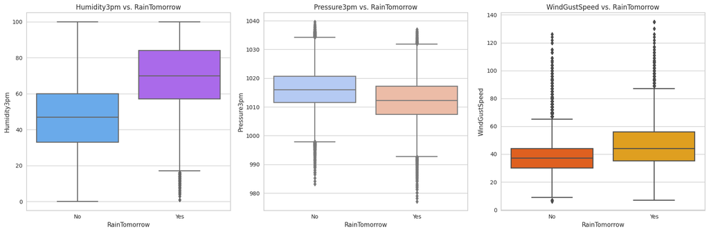

```python
fig, axs = plt.subplots(1, 3, figsize=(18, 6))

sns.boxplot(x='RainTomorrow', y='Humidity3pm', data=rain_df, ax=axs[0], palette='cool')
axs[0].set_title('Humidity3pm vs. RainTomorrow')

sns.boxplot(x='RainTomorrow', y='Pressure3pm', data=rain_df, ax=axs[1], palette='coolwarm')
axs[1].set_title('Pressure3pm vs. RainTomorrow')

sns.boxplot(x='RainTomorrow', y='WindGustSpeed', data=rain_df, ax=axs[2], palette='autumn')
axs[2].set_title('WindGustSpeed vs. RainTomorrow')

plt.tight_layout()
plt.show()
```

# 2) Data preprocessing

## 1. Preprocessing for supervised machine learning:

### Derive binary target attribute

The target attribute is RainTomorrow, which indicates whether it will rain the next day with "Yes" or "No". We will consider "Yes" as the positive value (1) and "No" as the negative value (0).

```python
rain_df
```

|  | Date | Location | MinTemp | MaxTemp | Rainfall | Evaporation | Sunshine | WindGustDir | WindGustSpeed | WindDir9am | ... | Humidity9am | Humidity3pm | Pressure9am | Pressure3pm | Cloud9am | Cloud3pm | Temp9am | Temp3pm | RainToday | RainTomorrow |
| --- | --- | --- | --- | --- | --- | --- | --- | --- | --- | --- | --- | --- | --- | --- | --- | --- | --- | --- | --- | --- | --- |
| 0 | 2008-12-01 | Albury | 13.4 | 22.9 | 0.6 | NaN | NaN | W | 44.0 | W | ... | 71.0 | 22.0 | 1007.7 | 1007.1 | 8.0 | NaN | 16.9 | 21.8 | No | No |
| 1 | 2008-12-02 | Albury | 7.4 | 25.1 | 0.0 | NaN | NaN | WNW | 44.0 | NNW | ... | 44.0 | 25.0 | 1010.6 | 1007.8 | NaN | NaN | 17.2 | 24.3 | No | No |
| 2 | 2008-12-03 | Albury | 12.9 | 25.7 | 0.0 | NaN | NaN | WSW | 46.0 | W | ... | 38.0 | 30.0 | 1007.6 | 1008.7 | NaN | 2.0 | 21.0 | 23.2 | No | No |
| 3 | 2008-12-04 | Albury | 9.2 | 28.0 | 0.0 | NaN | NaN | NE | 24.0 | SE | ... | 45.0 | 16.0 | 1017.6 | 1012.8 | NaN | NaN | 18.1 | 26.5 | No | No |
| 4 | 2008-12-05 | Albury | 17.5 | 32.3 | 1.0 | NaN | NaN | W | 41.0 | ENE | ... | 82.0 | 33.0 | 1010.8 | 1006.0 | 7.0 | 8.0 | 17.8 | 29.7 | No | No |
| ... | ... | ... | ... | ... | ... | ... | ... | ... | ... | ... | ... | ... | ... | ... | ... | ... | ... | ... | ... | ... | ... |
| 145455 | 2017-06-21 | Uluru | 2.8 | 23.4 | 0.0 | NaN | NaN | E | 31.0 | SE | ... | 51.0 | 24.0 | 1024.6 | 1020.3 | NaN | NaN | 10.1 | 22.4 | No | No |
| 145456 | 2017-06-22 | Uluru | 3.6 | 25.3 | 0.0 | NaN | NaN | NNW | 22.0 | SE | ... | 56.0 | 21.0 | 1023.5 | 1019.1 | NaN | NaN | 10.9 | 24.5 | No | No |
| 145457 | 2017-06-23 | Uluru | 5.4 | 26.9 | 0.0 | NaN | NaN | N | 37.0 | SE | ... | 53.0 | 24.0 | 1021.0 | 1016.8 | NaN | NaN | 12.5 | 26.1 | No | No |
| 145458 | 2017-06-24 | Uluru | 7.8 | 27.0 | 0.0 | NaN | NaN | SE | 28.0 | SSE | ... | 51.0 | 24.0 | 1019.4 | 1016.5 | 3.0 | 2.0 | 15.1 | 26.0 | No | No |
| 145459 | 2017-06-25 | Uluru | 14.9 | NaN | 0.0 | NaN | NaN | NaN | NaN | ESE | ... | 62.0 | 36.0 | 1020.2 | 1017.9 | 8.0 | 8.0 | 15.0 | 20.9 | No | NaN |

145460 rows × 23 columns

```python
rain_df['RainTomorrow'] = rain_df['RainTomorrow'].map({'Yes':1, 'No': 0})
rain_df['RainToday'] = rain_df['RainToday'].map({'Yes':1, 'No': 0})
rain_df
```

|  | Date | Location | MinTemp | MaxTemp | Rainfall | Evaporation | Sunshine | WindGustDir | WindGustSpeed | WindDir9am | ... | Humidity9am | Humidity3pm | Pressure9am | Pressure3pm | Cloud9am | Cloud3pm | Temp9am | Temp3pm | RainToday | RainTomorrow |
| --- | --- | --- | --- | --- | --- | --- | --- | --- | --- | --- | --- | --- | --- | --- | --- | --- | --- | --- | --- | --- | --- |
| 0 | 2008-12-01 | Albury | 13.4 | 22.9 | 0.6 | NaN | NaN | W | 44.0 | W | ... | 71.0 | 22.0 | 1007.7 | 1007.1 | 8.0 | NaN | 16.9 | 21.8 | 0.0 | 0.0 |
| 1 | 2008-12-02 | Albury | 7.4 | 25.1 | 0.0 | NaN | NaN | WNW | 44.0 | NNW | ... | 44.0 | 25.0 | 1010.6 | 1007.8 | NaN | NaN | 17.2 | 24.3 | 0.0 | 0.0 |
| 2 | 2008-12-03 | Albury | 12.9 | 25.7 | 0.0 | NaN | NaN | WSW | 46.0 | W | ... | 38.0 | 30.0 | 1007.6 | 1008.7 | NaN | 2.0 | 21.0 | 23.2 | 0.0 | 0.0 |
| 3 | 2008-12-04 | Albury | 9.2 | 28.0 | 0.0 | NaN | NaN | NE | 24.0 | SE | ... | 45.0 | 16.0 | 1017.6 | 1012.8 | NaN | NaN | 18.1 | 26.5 | 0.0 | 0.0 |
| 4 | 2008-12-05 | Albury | 17.5 | 32.3 | 1.0 | NaN | NaN | W | 41.0 | ENE | ... | 82.0 | 33.0 | 1010.8 | 1006.0 | 7.0 | 8.0 | 17.8 | 29.7 | 0.0 | 0.0 |
| ... | ... | ... | ... | ... | ... | ... | ... | ... | ... | ... | ... | ... | ... | ... | ... | ... | ... | ... | ... | ... | ... |
| 145455 | 2017-06-21 | Uluru | 2.8 | 23.4 | 0.0 | NaN | NaN | E | 31.0 | SE | ... | 51.0 | 24.0 | 1024.6 | 1020.3 | NaN | NaN | 10.1 | 22.4 | 0.0 | 0.0 |
| 145456 | 2017-06-22 | Uluru | 3.6 | 25.3 | 0.0 | NaN | NaN | NNW | 22.0 | SE | ... | 56.0 | 21.0 | 1023.5 | 1019.1 | NaN | NaN | 10.9 | 24.5 | 0.0 | 0.0 |
| 145457 | 2017-06-23 | Uluru | 5.4 | 26.9 | 0.0 | NaN | NaN | N | 37.0 | SE | ... | 53.0 | 24.0 | 1021.0 | 1016.8 | NaN | NaN | 12.5 | 26.1 | 0.0 | 0.0 |
| 145458 | 2017-06-24 | Uluru | 7.8 | 27.0 | 0.0 | NaN | NaN | SE | 28.0 | SSE | ... | 51.0 | 24.0 | 1019.4 | 1016.5 | 3.0 | 2.0 | 15.1 | 26.0 | 0.0 | 0.0 |
| 145459 | 2017-06-25 | Uluru | 14.9 | NaN | 0.0 | NaN | NaN | NaN | NaN | ESE | ... | 62.0 | 36.0 | 1020.2 | 1017.9 | 8.0 | 8.0 | 15.0 | 20.9 | 0.0 | NaN |

145460 rows × 23 columns

### Extracting time feature

```python
rain_df['Year'] = pd.to_datetime(rain_df['Date']).dt.year
rain_df['Month'] = pd.to_datetime(rain_df['Date']).dt.month
rain_df['Day'] = pd.to_datetime(rain_df['Date']).dt.day

rain_df = rain_df.drop('Date', axis=1)
```

```python
rain_df
```

|  | Location | MinTemp | MaxTemp | Rainfall | Evaporation | Sunshine | WindGustDir | WindGustSpeed | WindDir9am | WindDir3pm | ... | Pressure3pm | Cloud9am | Cloud3pm | Temp9am | Temp3pm | RainToday | RainTomorrow | Year | Month | Day |
| --- | --- | --- | --- | --- | --- | --- | --- | --- | --- | --- | --- | --- | --- | --- | --- | --- | --- | --- | --- | --- | --- |
| 0 | Albury | 13.4 | 22.9 | 0.6 | NaN | NaN | W | 44.0 | W | WNW | ... | 1007.1 | 8.0 | NaN | 16.9 | 21.8 | 0.0 | 0.0 | 2008 | 12 | 1 |
| 1 | Albury | 7.4 | 25.1 | 0.0 | NaN | NaN | WNW | 44.0 | NNW | WSW | ... | 1007.8 | NaN | NaN | 17.2 | 24.3 | 0.0 | 0.0 | 2008 | 12 | 2 |
| 2 | Albury | 12.9 | 25.7 | 0.0 | NaN | NaN | WSW | 46.0 | W | WSW | ... | 1008.7 | NaN | 2.0 | 21.0 | 23.2 | 0.0 | 0.0 | 2008 | 12 | 3 |
| 3 | Albury | 9.2 | 28.0 | 0.0 | NaN | NaN | NE | 24.0 | SE | E | ... | 1012.8 | NaN | NaN | 18.1 | 26.5 | 0.0 | 0.0 | 2008 | 12 | 4 |
| 4 | Albury | 17.5 | 32.3 | 1.0 | NaN | NaN | W | 41.0 | ENE | NW | ... | 1006.0 | 7.0 | 8.0 | 17.8 | 29.7 | 0.0 | 0.0 | 2008 | 12 | 5 |
| ... | ... | ... | ... | ... | ... | ... | ... | ... | ... | ... | ... | ... | ... | ... | ... | ... | ... | ... | ... | ... | ... |
| 145455 | Uluru | 2.8 | 23.4 | 0.0 | NaN | NaN | E | 31.0 | SE | ENE | ... | 1020.3 | NaN | NaN | 10.1 | 22.4 | 0.0 | 0.0 | 2017 | 6 | 21 |
| 145456 | Uluru | 3.6 | 25.3 | 0.0 | NaN | NaN | NNW | 22.0 | SE | N | ... | 1019.1 | NaN | NaN | 10.9 | 24.5 | 0.0 | 0.0 | 2017 | 6 | 22 |
| 145457 | Uluru | 5.4 | 26.9 | 0.0 | NaN | NaN | N | 37.0 | SE | WNW | ... | 1016.8 | NaN | NaN | 12.5 | 26.1 | 0.0 | 0.0 | 2017 | 6 | 23 |
| 145458 | Uluru | 7.8 | 27.0 | 0.0 | NaN | NaN | SE | 28.0 | SSE | N | ... | 1016.5 | 3.0 | 2.0 | 15.1 | 26.0 | 0.0 | 0.0 | 2017 | 6 | 24 |
| 145459 | Uluru | 14.9 | NaN | 0.0 | NaN | NaN | NaN | NaN | ESE | ESE | ... | 1017.9 | 8.0 | 8.0 | 15.0 | 20.9 | 0.0 | NaN | 2017 | 6 | 25 |

145460 rows × 25 columns

### Split the data into a training set and a test set

It is up to you what percentage will be used for training but the training set needs to be larger than the test set.

We will create a 70-30 split between training and test data.

```python
from sklearn.model_selection import train_test_split
```

```python
X_classification = rain_df.drop('RainTomorrow', axis=1)
y_classification = rain_df['RainTomorrow']
```

```python
train_set_classification, test_set_classification = train_test_split(rain_df, test_size=0.3, random_state=42)
len(train_set_classification), len(test_set_classification)
```

```
(101822, 43638)
```

### Handle missing values

We will now check the missing values in our dataset:

- Given that it's important not to leak information from the test set into the training process, let's proceed with handling missing values in the training set first.

```python
for column in train_set_classification.columns:
    print(f"The column {column} has {rain_df[column].isna().sum()} NaN values.")
```

```
The column Location has 0 NaN values.
The column MinTemp has 1485 NaN values.
The column MaxTemp has 1261 NaN values.
The column Rainfall has 3261 NaN values.
The column Evaporation has 62790 NaN values.
The column Sunshine has 69835 NaN values.
The column WindGustDir has 10326 NaN values.
The column WindGustSpeed has 10263 NaN values.
The column WindDir9am has 10566 NaN values.
The column WindDir3pm has 4228 NaN values.
The column WindSpeed9am has 1767 NaN values.
The column WindSpeed3pm has 3062 NaN values.
The column Humidity9am has 2654 NaN values.
The column Humidity3pm has 4507 NaN values.
The column Pressure9am has 15065 NaN values.
The column Pressure3pm has 15028 NaN values.
The column Cloud9am has 55888 NaN values.
The column Cloud3pm has 59358 NaN values.
The column Temp9am has 1767 NaN values.
The column Temp3pm has 3609 NaN values.
The column RainToday has 3261 NaN values.
The column RainTomorrow has 3267 NaN values.
The column Year has 0 NaN values.
The column Month has 0 NaN values.
The column Day has 0 NaN values.
```

We can display the missing percentage for each column

```python
missing_values = train_set_classification.isnull().sum()
missing_percentage = (missing_values / len(train_set_classification)) * 100
missing_info = missing_percentage[missing_percentage > 0].sort_values(ascending=False)
missing_info
```

```
Sunshine         48.044627
Evaporation      43.168470
Cloud3pm         40.804541
Cloud9am         38.432755
Pressure9am      10.361219
Pressure3pm      10.347469
WindDir9am        7.263656
WindGustDir       7.057414
WindGustSpeed     7.017148
Humidity3pm       3.122115
WindDir3pm        2.910962
Temp3pm           2.493567
Rainfall          2.241166
RainToday         2.241166
RainTomorrow      2.228399
WindSpeed3pm      2.099743
Humidity9am       1.842431
Temp9am           1.217811
WindSpeed9am      1.214865
MinTemp           1.006659
MaxTemp           0.847558
dtype: float64
```

We will drop the columns which have more than 20% of missing data as they won't provide reliable information due to the amount of missing data:

```python
train_set_classification = train_set_classification.drop(columns=['Sunshine', 'Evaporation', 'Cloud3pm', 'Cloud9am'])
test_set_classification = test_set_classification.drop(columns=['Sunshine', 'Evaporation', 'Cloud3pm', 'Cloud9am'])
```

For columns with less than 20% of missing data we will do data imputation for:

- numerical columns:

```python
rain_df
```

|  | Location | MinTemp | MaxTemp | Rainfall | Evaporation | Sunshine | WindGustDir | WindGustSpeed | WindDir9am | WindDir3pm | ... | Pressure3pm | Cloud9am | Cloud3pm | Temp9am | Temp3pm | RainToday | RainTomorrow | Year | Month | Day |
| --- | --- | --- | --- | --- | --- | --- | --- | --- | --- | --- | --- | --- | --- | --- | --- | --- | --- | --- | --- | --- | --- |
| 0 | Albury | 13.4 | 22.9 | 0.6 | NaN | NaN | W | 44.0 | W | WNW | ... | 1007.1 | 8.0 | NaN | 16.9 | 21.8 | 0.0 | 0.0 | 2008 | 12 | 1 |
| 1 | Albury | 7.4 | 25.1 | 0.0 | NaN | NaN | WNW | 44.0 | NNW | WSW | ... | 1007.8 | NaN | NaN | 17.2 | 24.3 | 0.0 | 0.0 | 2008 | 12 | 2 |
| 2 | Albury | 12.9 | 25.7 | 0.0 | NaN | NaN | WSW | 46.0 | W | WSW | ... | 1008.7 | NaN | 2.0 | 21.0 | 23.2 | 0.0 | 0.0 | 2008 | 12 | 3 |
| 3 | Albury | 9.2 | 28.0 | 0.0 | NaN | NaN | NE | 24.0 | SE | E | ... | 1012.8 | NaN | NaN | 18.1 | 26.5 | 0.0 | 0.0 | 2008 | 12 | 4 |
| 4 | Albury | 17.5 | 32.3 | 1.0 | NaN | NaN | W | 41.0 | ENE | NW | ... | 1006.0 | 7.0 | 8.0 | 17.8 | 29.7 | 0.0 | 0.0 | 2008 | 12 | 5 |
| ... | ... | ... | ... | ... | ... | ... | ... | ... | ... | ... | ... | ... | ... | ... | ... | ... | ... | ... | ... | ... | ... |
| 145455 | Uluru | 2.8 | 23.4 | 0.0 | NaN | NaN | E | 31.0 | SE | ENE | ... | 1020.3 | NaN | NaN | 10.1 | 22.4 | 0.0 | 0.0 | 2017 | 6 | 21 |
| 145456 | Uluru | 3.6 | 25.3 | 0.0 | NaN | NaN | NNW | 22.0 | SE | N | ... | 1019.1 | NaN | NaN | 10.9 | 24.5 | 0.0 | 0.0 | 2017 | 6 | 22 |
| 145457 | Uluru | 5.4 | 26.9 | 0.0 | NaN | NaN | N | 37.0 | SE | WNW | ... | 1016.8 | NaN | NaN | 12.5 | 26.1 | 0.0 | 0.0 | 2017 | 6 | 23 |
| 145458 | Uluru | 7.8 | 27.0 | 0.0 | NaN | NaN | SE | 28.0 | SSE | N | ... | 1016.5 | 3.0 | 2.0 | 15.1 | 26.0 | 0.0 | 0.0 | 2017 | 6 | 24 |
| 145459 | Uluru | 14.9 | NaN | 0.0 | NaN | NaN | NaN | NaN | ESE | ESE | ... | 1017.9 | 8.0 | 8.0 | 15.0 | 20.9 | 0.0 | NaN | 2017 | 6 | 25 |

145460 rows × 25 columns

```python
from sklearn.impute import SimpleImputer

num_imputer = SimpleImputer(strategy='median')

num_columns = ['Pressure9am','Pressure3pm','WindGustSpeed','Humidity3pm','Temp3pm','Temp9am','Rainfall',
'WindSpeed3pm','WindSpeed9am','Humidity9am','MinTemp','MaxTemp']

for column in num_columns:
    train_set_classification[[column]] = num_imputer.fit_transform(train_set_classification[[column]])
    test_set_classification[[column]] = num_imputer.fit_transform(test_set_classification[[column]])
```

```python
train_set_classification[num_columns].head(20)
```

|  | Pressure9am | Pressure3pm | WindGustSpeed | Humidity3pm | Temp3pm | Temp9am | Rainfall | WindSpeed3pm | WindSpeed9am | Humidity9am | MinTemp | MaxTemp |
| --- | --- | --- | --- | --- | --- | --- | --- | --- | --- | --- | --- | --- |
| 141565 | 1013.3 | 1009.4 | 48.0 | 27.0 | 33.4 | 25.7 | 0.0 | 19.0 | 19.0 | 66.0 | 22.2 | 34.2 |
| 85325 | 1013.3 | 1011.4 | 20.0 | 50.0 | 29.4 | 24.7 | 0.0 | 7.0 | 7.0 | 50.0 | 16.9 | 31.4 |
| 17847 | 1017.6 | 1015.2 | 39.0 | 52.0 | 21.1 | 17.0 | 2.4 | 19.0 | 28.0 | 39.0 | 8.8 | 20.9 |
| 69746 | 1017.6 | 1015.2 | 28.0 | 52.0 | 21.1 | 16.7 | 0.0 | 19.0 | 11.0 | 70.0 | 12.0 | 22.6 |
| 98356 | 1016.1 | 1017.1 | 35.0 | 60.0 | 19.3 | 18.2 | 1.2 | 17.0 | 13.0 | 75.0 | 11.8 | 21.3 |
| 45159 | 1030.5 | 1029.6 | 35.0 | 69.0 | 19.6 | 18.1 | 9.6 | 11.0 | 19.0 | 81.0 | 15.0 | 20.4 |
| 72892 | 1002.7 | 997.9 | 52.0 | 33.0 | 32.2 | 23.6 | 0.0 | 24.0 | 19.0 | 44.0 | 18.6 | 35.6 |
| 121085 | 1009.7 | 1011.7 | 72.0 | 72.0 | 13.5 | 15.0 | 2.6 | 24.0 | 15.0 | 71.0 | 12.7 | 17.8 |
| 9427 | 1018.8 | 1016.9 | 31.0 | 70.0 | 25.8 | 23.3 | 0.0 | 20.0 | 11.0 | 66.0 | 15.9 | 26.7 |
| 31676 | 1024.5 | 1025.9 | 65.0 | 40.0 | 18.0 | 15.5 | 0.0 | 33.0 | 31.0 | 45.0 | 10.1 | 19.1 |
| 71378 | 1019.2 | 1015.6 | 33.0 | 23.0 | 24.6 | 14.7 | 0.0 | 9.0 | 11.0 | 57.0 | 8.4 | 26.4 |
| 55399 | 1011.3 | 1009.0 | 39.0 | 61.0 | 14.8 | 10.0 | 0.8 | 31.0 | 30.0 | 96.0 | 6.4 | 15.6 |
| 116401 | 1009.6 | 1006.2 | 44.0 | 32.0 | 33.3 | 26.1 | 0.0 | 28.0 | 11.0 | 48.0 | 20.0 | 35.1 |
| 9928 | 1017.6 | 1014.8 | 26.0 | 48.0 | 17.4 | 12.6 | 0.0 | 11.0 | 4.0 | 74.0 | 4.3 | 18.1 |
| 52249 | 1017.6 | 1015.2 | 43.0 | 52.0 | 21.1 | 16.7 | 0.0 | 19.0 | 13.0 | 70.0 | 12.0 | 3.2 |
| 31067 | 1022.2 | 1019.8 | 39.0 | 76.0 | 17.3 | 16.7 | 0.2 | 7.0 | 13.0 | 61.0 | 9.9 | 19.0 |
| 72198 | 1018.2 | 1016.3 | 35.0 | 14.0 | 37.4 | 24.8 | 0.0 | 17.0 | 13.0 | 39.0 | 19.0 | 38.2 |
| 134230 | 1027.6 | 1024.3 | 33.0 | 64.0 | 18.8 | 11.9 | 0.0 | 20.0 | 4.0 | 85.0 | 5.0 | 19.8 |
| 102259 | 1029.3 | 1027.1 | 35.0 | 79.0 | 14.6 | 12.7 | 0.8 | 13.0 | 20.0 | 89.0 | 10.4 | 15.9 |
| 12222 | 1018.3 | 1014.8 | 30.0 | 39.0 | 19.1 | 12.5 | 0.2 | 15.0 | 11.0 | 70.0 | 8.5 | 19.5 |

```python
missing_values = train_set_classification.isnull().sum()
missing_percentage = (missing_values / len(train_set_classification)) * 100
missing_info = missing_percentage[missing_percentage > 0].sort_values(ascending=False)
missing_info
```

```
WindDir9am      7.263656
WindGustDir     7.057414
WindDir3pm      2.910962
RainToday       2.241166
RainTomorrow    2.228399
dtype: float64
```

- categorical columns:

We will not impute missing values in the target variable column as this would introduce significant bias into our models.

```python
cat_imputer = SimpleImputer(strategy='most_frequent')

cat_columns = ['WindDir9am','WindGustDir','WindDir3pm','RainToday']

for column in cat_columns:
    train_set_classification[[column]] = cat_imputer.fit_transform(train_set_classification[[column]])
    test_set_classification[[column]] = cat_imputer.fit_transform(test_set_classification[[column]])
```

```python
missing_values = train_set_classification.isnull().sum()
missing_percentage = (missing_values / len(train_set_classification)) * 100
missing_info = missing_percentage[missing_percentage > 0].sort_values(ascending=False)
missing_info
```

```
RainTomorrow    2.228399
dtype: float64
```

We will remove those rows where the target variable value is missing:

```python
print("Number of rows before removing missing target values:", len(train_set_classification))

train_set_classification = train_set_classification.dropna(subset=['RainTomorrow'])
test_set_classification = test_set_classification.dropna(subset=['RainTomorrow'])

print("Number of rows after removing missing target values:", len(train_set_classification))
```

```
Number of rows before removing missing target values: 101822
Number of rows after removing missing target values: 99553
```

We have successfully handled all the missing data in our dataset.

### Handle imbalance

We will now check the class imbalance in our dataset:

```python
# Check the class distribution
class_distribution = train_set_classification['RainTomorrow'].value_counts()
print(class_distribution)
```

```
RainTomorrow
0.0    77327
1.0    22226
Name: count, dtype: int64
```

There is a class imbalance in our dataset, we will upsample our minority class to match the count of the majority class:

```python
from sklearn.utils import resample

df_majority = train_set_classification[train_set_classification.RainTomorrow==0]
df_minority = train_set_classification[train_set_classification.RainTomorrow==1]

df_minority_upsampled = resample(df_minority, replace=True,n_samples=len(df_majority), random_state=123)

df_upsampled = pd.concat([df_majority, df_minority_upsampled])

print(df_upsampled.RainTomorrow.value_counts())
```

```
RainTomorrow
0.0    77327
1.0    77327
Name: count, dtype: int64
```

```python
train_set_classification = df_upsampled
```

We have successfully performed resampling the training set, it was important to keep the test data as a realistic representation of the original dataset, therefore we have not resampled the test set.

```python
train_set_classification.WindDir3pm.unique()
```

```
array(['E', 'ENE', 'SE', 'SSE', 'NNE', 'SSW', 'SW', 'NW', 'NNW', 'WNW',
       'NE', 'ESE', 'S', 'WSW', 'N', 'W'], dtype=object)
```

Each wind direction column contains a large number of unique values, encoding 16 values for each of our three categorical columns would introduce 48 new columns which could lead to the curse of dimensionality and possible long training times.

```python
directions_to_degrees = {
    'N': 0, 'NNE': 22.5, 'NE': 45, 'ENE': 67.5,
    'E': 90, 'ESE': 112.5, 'SE': 135, 'SSE': 157.5,
    'S': 180, 'SSW': 202.5, 'SW': 225, 'WSW': 247.5,
    'W': 270, 'WNW': 292.5, 'NW': 315, 'NNW': 337.5
}

def convert_wind_direction(df, column):
    degrees = df[column].map(directions_to_degrees)
    df[column+'_sin'] = np.sin(np.radians(degrees))
    df[column+'_cos'] = np.cos(np.radians(degrees))
    return df

for col in ['WindDir9am', 'WindGustDir', 'WindDir3pm']:
    train_set_classification = convert_wind_direction(train_set_classification, col)
    test_set_classification = convert_wind_direction(test_set_classification, col)

train_set_classification = train_set_classification.drop(['WindDir9am', 'WindGustDir', 'WindDir3pm'], axis=1)
test_set_classification = test_set_classification.drop(['WindDir9am', 'WindGustDir', 'WindDir3pm'], axis=1)
```

```python
print(train_set_classification.columns)
train_set_classification
```

```
Index(['Location', 'MinTemp', 'MaxTemp', 'Rainfall', 'WindGustSpeed',
       'WindSpeed9am', 'WindSpeed3pm', 'Humidity9am', 'Humidity3pm',
       'Pressure9am', 'Pressure3pm', 'Temp9am', 'Temp3pm', 'RainToday',
       'RainTomorrow', 'Year', 'Month', 'Day', 'WindDir9am_sin',
       'WindDir9am_cos', 'WindGustDir_sin', 'WindGustDir_cos',
       'WindDir3pm_sin', 'WindDir3pm_cos'],
      dtype='object')
```

|  | Location | MinTemp | MaxTemp | Rainfall | WindGustSpeed | WindSpeed9am | WindSpeed3pm | Humidity9am | Humidity3pm | Pressure9am | ... | RainTomorrow | Year | Month | Day | WindDir9am_sin | WindDir9am_cos | WindGustDir_sin | WindGustDir_cos | WindDir3pm_sin | WindDir3pm_cos |
| --- | --- | --- | --- | --- | --- | --- | --- | --- | --- | --- | --- | --- | --- | --- | --- | --- | --- | --- | --- | --- | --- |
| 141565 | Darwin | 22.2 | 34.2 | 0.0 | 48.0 | 19.0 | 19.0 | 66.0 | 27.0 | 1013.3 | ... | 0.0 | 2015 | 6 | 18 | 0.707107 | -7.071068e-01 | 1.000000e+00 | 6.123234e-17 | 1.000000 | 6.123234e-17 |
| 85325 | Brisbane | 16.9 | 31.4 | 0.0 | 20.0 | 7.0 | 7.0 | 50.0 | 50.0 | 1013.3 | ... | 0.0 | 2012 | 3 | 10 | -0.923880 | -3.826834e-01 | 1.000000e+00 | 6.123234e-17 | 0.923880 | 3.826834e-01 |
| 17847 | Newcastle | 8.8 | 20.9 | 2.4 | 39.0 | 28.0 | 19.0 | 39.0 | 52.0 | 1017.6 | ... | 0.0 | 2016 | 9 | 30 | 0.000000 | 1.000000e+00 | -1.000000e+00 | -1.836970e-16 | 0.707107 | -7.071068e-01 |
| 98356 | Adelaide | 11.8 | 21.3 | 1.2 | 35.0 | 13.0 | 17.0 | 75.0 | 60.0 | 1016.1 | ... | 0.0 | 2014 | 4 | 26 | -0.382683 | -9.238795e-01 | 1.224647e-16 | -1.000000e+00 | 0.382683 | -9.238795e-01 |
| 45159 | Wollongong | 15.0 | 20.4 | 9.6 | 35.0 | 19.0 | 11.0 | 81.0 | 69.0 | 1030.5 | ... | 0.0 | 2016 | 4 | 24 | -0.382683 | -9.238795e-01 | -3.826834e-01 | -9.238795e-01 | 0.382683 | -9.238795e-01 |
| ... | ... | ... | ... | ... | ... | ... | ... | ... | ... | ... | ... | ... | ... | ... | ... | ... | ... | ... | ... | ... | ... |
| 35906 | SydneyAirport | 16.7 | 29.7 | 2.2 | 59.0 | 13.0 | 24.0 | 48.0 | 63.0 | 1016.6 | ... | 1.0 | 2015 | 10 | 12 | -0.707107 | 7.071068e-01 | 1.224647e-16 | -1.000000e+00 | 0.923880 | 3.826834e-01 |
| 87299 | Cairns | 24.6 | 31.3 | 0.0 | 39.0 | 6.0 | 13.0 | 88.0 | 73.0 | 1010.4 | ... | 1.0 | 2009 | 3 | 10 | -1.000000 | -1.836970e-16 | -1.000000e+00 | -1.836970e-16 | 1.000000 | 6.123234e-17 |
| 117250 | PearceRAAF | 11.2 | 21.1 | 0.0 | 59.0 | 19.0 | 19.0 | 55.0 | 53.0 | 1019.3 | ... | 1.0 | 2016 | 6 | 12 | 0.000000 | 1.000000e+00 | -1.000000e+00 | -1.836970e-16 | 0.000000 | 1.000000e+00 |
| 85691 | Brisbane | 14.3 | 24.4 | 0.0 | 30.0 | 2.0 | 11.0 | 71.0 | 58.0 | 1028.8 | ... | 1.0 | 2013 | 5 | 9 | -0.382683 | -9.238795e-01 | 7.071068e-01 | -7.071068e-01 | 0.382683 | -9.238795e-01 |
| 124024 | SalmonGums | 6.4 | 14.5 | 0.4 | 44.0 | 19.0 | 22.0 | 81.0 | 55.0 | 1017.6 | ... | 1.0 | 2009 | 7 | 13 | -1.000000 | -1.836970e-16 | -9.238795e-01 | -3.826834e-01 | -0.707107 | -7.071068e-01 |

154654 rows × 24 columns

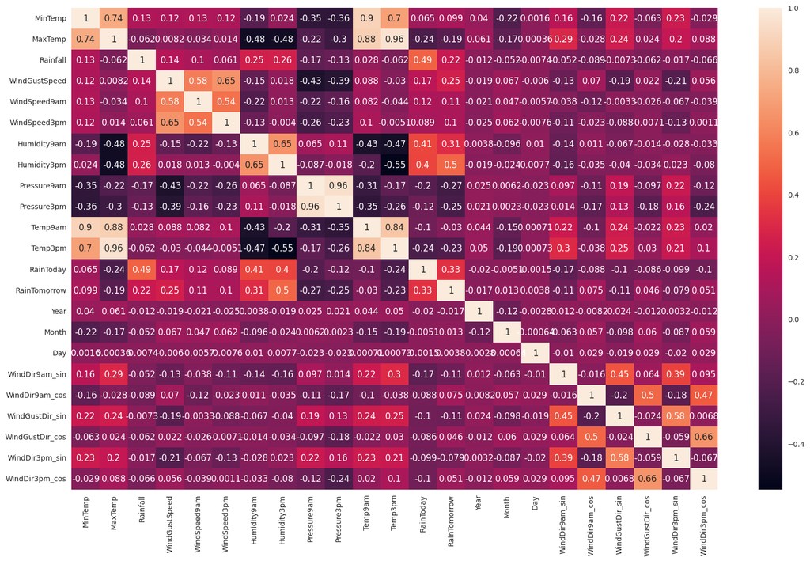

```python
cor = train_set_classification.drop(columns=['Location']).corr()
plt.figure(figsize = (20,12))
sns.heatmap(cor, annot=True)
```

We also need to do encode Location column into numbers:

```python
train_set_classification.Location.unique()
```

```
array(['Darwin', 'Brisbane', 'Newcastle', 'Adelaide', 'Wollongong',
       'Mildura', 'CoffsHarbour', 'Sydney', 'PearceRAAF', 'Launceston',
       'MountGambier', 'Moree', 'Townsville', 'Witchcliffe', 'Perth',
       'Penrith', 'Canberra', 'Walpole', 'Uluru', 'NorfolkIsland',
       'AliceSprings', 'Richmond', 'Portland', 'Cairns', 'GoldCoast',
       'SydneyAirport', 'MountGinini', 'BadgerysCreek', 'Melbourne',
       'Williamtown', 'Hobart', 'Nuriootpa', 'Sale', 'WaggaWagga',
       'Bendigo', 'SalmonGums', 'MelbourneAirport', 'NorahHead',
       'Ballarat', 'Watsonia', 'Albany', 'Albury', 'Cobar', 'Woomera',
       'Dartmoor', 'PerthAirport', 'Tuggeranong', 'Nhil', 'Katherine'],
      dtype=object)
```

```python
la = LabelEncoder()
train_set_classification.Location = la.fit_transform(train_set_classification.Location)
test_set_classification.Location = la.fit_transform(test_set_classification.Location)
```

```python
train_set_classification['Location']
```

```
141565    13
85325      7
17847     24
98356      0
45159     47
          ..
35906     38
87299      8
117250    29
85691      7
124024    36
Name: Location, Length: 154654, dtype: int64
```

```python
train_set_classification.columns
```

```
Index(['Location', 'MinTemp', 'MaxTemp', 'Rainfall', 'WindGustSpeed',
       'WindSpeed9am', 'WindSpeed3pm', 'Humidity9am', 'Humidity3pm',
       'Pressure9am', 'Pressure3pm', 'Temp9am', 'Temp3pm', 'RainToday',
       'RainTomorrow', 'Year', 'Month', 'Day', 'WindDir9am_sin',
       'WindDir9am_cos', 'WindGustDir_sin', 'WindGustDir_cos',
       'WindDir3pm_sin', 'WindDir3pm_cos'],
      dtype='object')
```

### Feature selection

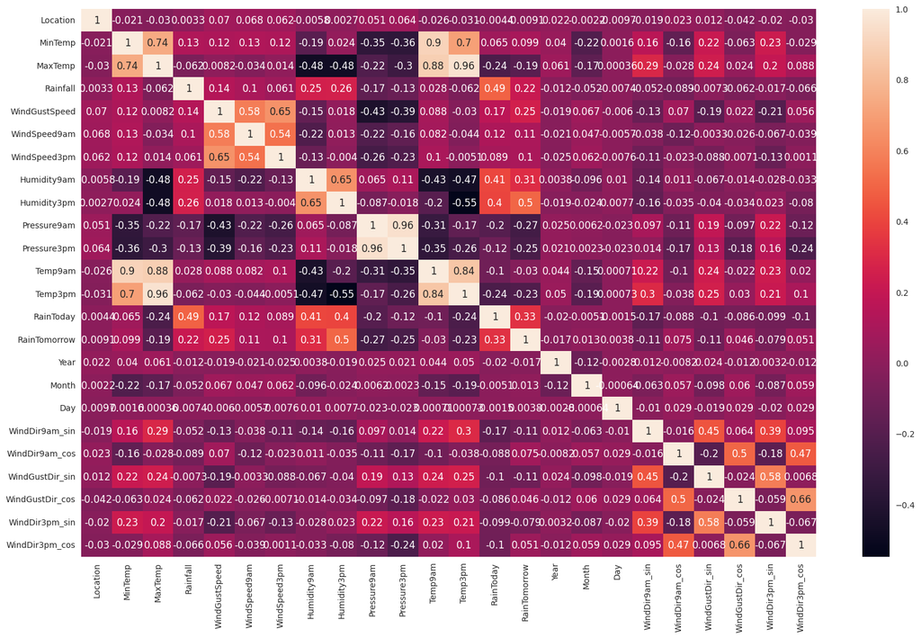

```python
cor = train_set_classification.corr()
plt.figure(figsize = (20,12))
sns.heatmap(cor, annot=True)
```

The location data column shows low correlation.

The columns Location, Year, Month and Day are uncorrelated with the target atribute therefore we will drop these.

```python
train_set_classification = train_set_classification.drop(columns=['Location','Day', 'Month', 'Year'])
```

```python
test_set_classification = test_set_classification.drop(columns=['Location', 'Day', 'Month', 'Year'])
```

```python
data_set_clustering = pd.concat([train_set_classification, test_set_classification], ignore_index=True)
data_set_clustering
```

|  | MinTemp | MaxTemp | Rainfall | WindGustSpeed | WindSpeed9am | WindSpeed3pm | Humidity9am | Humidity3pm | Pressure9am | Pressure3pm | Temp9am | Temp3pm | RainToday | RainTomorrow | WindDir9am_sin | WindDir9am_cos | WindGustDir_sin | WindGustDir_cos | WindDir3pm_sin | WindDir3pm_cos |
| --- | --- | --- | --- | --- | --- | --- | --- | --- | --- | --- | --- | --- | --- | --- | --- | --- | --- | --- | --- | --- |
| 0 | 22.2 | 34.2 | 0.0 | 48.0 | 19.0 | 19.0 | 66.0 | 27.0 | 1013.3 | 1009.4 | 25.7 | 33.4 | 0.0 | 0.0 | 0.707107 | -0.707107 | 1.000000e+00 | 6.123234e-17 | 1.000000 | 6.123234e-17 |
| 1 | 16.9 | 31.4 | 0.0 | 20.0 | 7.0 | 7.0 | 50.0 | 50.0 | 1013.3 | 1011.4 | 24.7 | 29.4 | 0.0 | 0.0 | -0.923880 | -0.382683 | 1.000000e+00 | 6.123234e-17 | 0.923880 | 3.826834e-01 |
| 2 | 8.8 | 20.9 | 2.4 | 39.0 | 28.0 | 19.0 | 39.0 | 52.0 | 1017.6 | 1015.2 | 17.0 | 21.1 | 1.0 | 0.0 | 0.000000 | 1.000000 | -1.000000e+00 | -1.836970e-16 | 0.707107 | -7.071068e-01 |
| 3 | 11.8 | 21.3 | 1.2 | 35.0 | 13.0 | 17.0 | 75.0 | 60.0 | 1016.1 | 1017.1 | 18.2 | 19.3 | 1.0 | 0.0 | -0.382683 | -0.923880 | 1.224647e-16 | -1.000000e+00 | 0.382683 | -9.238795e-01 |
| 4 | 15.0 | 20.4 | 9.6 | 35.0 | 19.0 | 11.0 | 81.0 | 69.0 | 1030.5 | 1029.6 | 18.1 | 19.6 | 1.0 | 0.0 | -0.382683 | -0.923880 | -3.826834e-01 | -9.238795e-01 | 0.382683 | -9.238795e-01 |
| ... | ... | ... | ... | ... | ... | ... | ... | ... | ... | ... | ... | ... | ... | ... | ... | ... | ... | ... | ... | ... |
| 197289 | 8.9 | 24.2 | 0.0 | 52.0 | 28.0 | 28.0 | 59.0 | 29.0 | 1016.0 | 1008.5 | 12.0 | 23.3 | 0.0 | 1.0 | 0.000000 | 1.000000 | -3.826834e-01 | 9.238795e-01 | 0.000000 | 1.000000e+00 |
| 197290 | 15.8 | 29.8 | 0.0 | 39.0 | 7.0 | 4.0 | 81.0 | 40.0 | 1021.4 | 1018.2 | 18.4 | 29.0 | 0.0 | 1.0 | 0.000000 | 1.000000 | 9.238795e-01 | -3.826834e-01 | -0.923880 | 3.826834e-01 |
| 197291 | 18.1 | 21.4 | 4.4 | 67.0 | 13.0 | 41.0 | 77.0 | 80.0 | 1022.0 | 1021.2 | 18.2 | 20.6 | 1.0 | 1.0 | -0.707107 | -0.707107 | 1.224647e-16 | -1.000000e+00 | -0.382683 | -9.238795e-01 |
| 197292 | 4.6 | 17.4 | 0.0 | 46.0 | 11.0 | 24.0 | 59.0 | 32.0 | 1022.0 | 1019.9 | 11.3 | 16.3 | 0.0 | 0.0 | -0.382683 | -0.923880 | -7.071068e-01 | -7.071068e-01 | -0.707107 | -7.071068e-01 |
| 197293 | 14.2 | 23.4 | 0.4 | 52.0 | 17.0 | 17.0 | 75.0 | 68.0 | 1005.0 | 1000.9 | 17.9 | 21.9 | 0.0 | 0.0 | 0.923880 | 0.382683 | -7.071068e-01 | -7.071068e-01 | 0.707107 | 7.071068e-01 |

197294 rows × 20 columns

### Rescaling

We will now rescale our features using standard scaler:

```python
train_set_classification.iloc[17847]
```

```
MinTemp            1.820000e+01
MaxTemp            2.110000e+01
Rainfall           0.000000e+00
WindGustSpeed      3.900000e+01
WindSpeed9am       1.900000e+01
WindSpeed3pm       1.900000e+01
Humidity9am        7.100000e+01
Humidity3pm        7.200000e+01
Pressure9am        1.015900e+03
Pressure3pm        1.015800e+03
Temp9am            1.940000e+01
Temp3pm            2.000000e+01
RainToday          0.000000e+00
RainTomorrow       0.000000e+00
WindDir9am_sin     1.224647e-16
WindDir9am_cos    -1.000000e+00
WindGustDir_sin   -1.000000e+00
WindGustDir_cos   -1.836970e-16
WindDir3pm_sin     3.826834e-01
WindDir3pm_cos    -9.238795e-01
Name: 108649, dtype: float64
```

```python
from sklearn.preprocessing import StandardScaler
columns_to_exclude = ['RainTomorrow', 'RainToday'] + [col for col in train_set_classification.columns if col.startswith('Location_')]

numerical_columns = [col for col in train_set_classification.columns if col not in columns_to_exclude]

scaler = StandardScaler()

train_set_classification[numerical_columns] = scaler.fit_transform(train_set_classification[numerical_columns])

test_set_classification[numerical_columns] = scaler.fit_transform(test_set_classification[numerical_columns])
```

```python
train_set_classification.head()
```

|  | MinTemp | MaxTemp | Rainfall | WindGustSpeed | WindSpeed9am | WindSpeed3pm | Humidity9am | Humidity3pm | Pressure9am | Pressure3pm | Temp9am | Temp3pm | RainToday | RainTomorrow | WindDir9am_sin | WindDir9am_cos | WindGustDir_sin | WindGustDir_cos | WindDir3pm_sin | WindDir3pm_cos |
| --- | --- | --- | --- | --- | --- | --- | --- | --- | --- | --- | --- | --- | --- | --- | --- | --- | --- | --- | --- | --- |
| 141565 | 1.518111 | 1.650779 | -0.334382 | 0.426341 | 0.488516 | -0.017409 | -0.329814 | -1.414710 | -0.467248 | -0.701141 | 1.376093 | 1.834137 | 0.0 | 0.0 | 1.103868 | -1.103837 | 1.561465 | 0.043249 | 1.457773 | 0.063192 |
| 85325 | 0.686653 | 1.256648 | -0.334382 | -1.539902 | -0.823359 | -1.334442 | -1.198422 | -0.344639 | -0.467248 | -0.413848 | 1.220306 | 1.251198 | 0.0 | 0.0 | -1.359149 | -0.665871 | 1.561465 | 0.043249 | 1.350176 | 0.606274 |
| 17847 | -0.584066 | -0.221343 | -0.112828 | -0.205666 | 1.472423 | -0.017409 | -1.795591 | -0.251589 | 0.144995 | 0.132007 | 0.020748 | 0.041600 | 1.0 | 0.0 | 0.036038 | 1.200728 | -1.209732 | 0.043249 | 1.043767 | -0.940292 |
| 98356 | -0.113429 | -0.165039 | -0.223605 | -0.486558 | -0.167421 | -0.236914 | 0.158778 | 0.120609 | -0.068578 | 0.404935 | 0.207692 | -0.220722 | 1.0 | 0.0 | -0.541867 | -1.396476 | 0.175866 | -1.427719 | 0.585194 | -1.247923 |
| 45159 | 0.388583 | -0.291724 | 0.551832 | -0.486558 | 0.488516 | -0.895431 | 0.484506 | 0.539332 | 1.981722 | 2.200514 | 0.192113 | -0.177002 | 1.0 | 0.0 | -0.541867 | -1.396476 | -0.354379 | -1.315748 | 0.585194 | -1.247923 |

We have successfully preprocessed the data for the classification task, the data is stored under the variables train_set_classification and test_set_classification for further tasks such as modelling.

# 3) Modelling

Carefully describe all parameters used in the report:

```python
train_set_classification
```

|  | MinTemp | MaxTemp | Rainfall | WindGustSpeed | WindSpeed9am | WindSpeed3pm | Humidity9am | Humidity3pm | Pressure9am | Pressure3pm | Temp9am | Temp3pm | RainToday | RainTomorrow | WindDir9am_sin | WindDir9am_cos | WindGustDir_sin | WindGustDir_cos | WindDir3pm_sin | WindDir3pm_cos |
| --- | --- | --- | --- | --- | --- | --- | --- | --- | --- | --- | --- | --- | --- | --- | --- | --- | --- | --- | --- | --- |
| 141565 | 1.518111 | 1.650779 | -0.334382 | 0.426341 | 0.488516 | -0.017409 | -0.329814 | -1.414710 | -0.467248 | -0.701141 | 1.376093 | 1.834137 | 0.0 | 0.0 | 1.103868 | -1.103837 | 1.561465 | 0.043249 | 1.457773 | 0.063192 |
| 85325 | 0.686653 | 1.256648 | -0.334382 | -1.539902 | -0.823359 | -1.334442 | -1.198422 | -0.344639 | -0.467248 | -0.413848 | 1.220306 | 1.251198 | 0.0 | 0.0 | -1.359149 | -0.665871 | 1.561465 | 0.043249 | 1.350176 | 0.606274 |
| 17847 | -0.584066 | -0.221343 | -0.112828 | -0.205666 | 1.472423 | -0.017409 | -1.795591 | -0.251589 | 0.144995 | 0.132007 | 0.020748 | 0.041600 | 1.0 | 0.0 | 0.036038 | 1.200728 | -1.209732 | 0.043249 | 1.043767 | -0.940292 |
| 98356 | -0.113429 | -0.165039 | -0.223605 | -0.486558 | -0.167421 | -0.236914 | 0.158778 | 0.120609 | -0.068578 | 0.404935 | 0.207692 | -0.220722 | 1.0 | 0.0 | -0.541867 | -1.396476 | 0.175866 | -1.427719 | 0.585194 | -1.247923 |
| 45159 | 0.388583 | -0.291724 | 0.551832 | -0.486558 | 0.488516 | -0.895431 | 0.484506 | 0.539332 | 1.981722 | 2.200514 | 0.192113 | -0.177002 | 1.0 | 0.0 | -0.541867 | -1.396476 | -0.354379 | -1.315748 | 0.585194 | -1.247923 |
| ... | ... | ... | ... | ... | ... | ... | ... | ... | ... | ... | ... | ... | ... | ... | ... | ... | ... | ... | ... | ... |
| 35906 | 0.655277 | 1.017354 | -0.131291 | 1.198793 | -0.167421 | 0.531355 | -1.306998 | 0.260184 | 0.002613 | -0.298931 | 0.939890 | 0.289349 | 1.0 | 1.0 | -1.031792 | 0.805328 | 0.175866 | -1.427719 | 1.350176 | 0.606274 |
| 87299 | 1.894620 | 1.242572 | -0.334382 | -0.205666 | -0.932682 | -0.675926 | 0.864522 | 0.725432 | -0.880156 | -1.002798 | 1.453986 | 1.353212 | 0.0 | 1.0 | -1.474101 | -0.149255 | -1.209732 | 0.043249 | 1.457773 | 0.063192 |
| 117250 | -0.207557 | -0.193191 | -0.334382 | 1.198793 | 0.488516 | -0.017409 | -0.926982 | -0.205065 | 0.387044 | -0.083462 | -0.212932 | -0.220722 | 0.0 | 1.0 | 0.036038 | 1.200728 | -1.209732 | 0.043249 | 0.044269 | 1.482333 |
| 85691 | 0.278768 | 0.271320 | -0.334382 | -0.837673 | -1.369973 | -0.895431 | -0.058374 | 0.027559 | 1.739673 | 1.611564 | 0.347900 | 0.129041 | 0.0 | 1.0 | -0.541867 | -1.396476 | 1.155633 | -0.996883 | 0.585194 | -1.247923 |
| 124024 | -0.960576 | -1.122214 | -0.297456 | 0.145449 | 0.488516 | 0.311850 | 0.484506 | -0.112015 | 0.144995 | 0.132007 | -1.163232 | -0.920249 | 0.0 | 1.0 | -1.474101 | -0.149255 | -1.104260 | -0.519666 | -0.955228 | -0.940292 |

154654 rows × 20 columns

```python
test_set_classification
```

|  | MinTemp | MaxTemp | Rainfall | WindGustSpeed | WindSpeed9am | WindSpeed3pm | Humidity9am | Humidity3pm | Pressure9am | Pressure3pm | Temp9am | Temp3pm | RainToday | RainTomorrow | WindDir9am_sin | WindDir9am_cos | WindGustDir_sin | WindGustDir_cos | WindDir3pm_sin | WindDir3pm_cos |
| --- | --- | --- | --- | --- | --- | --- | --- | --- | --- | --- | --- | --- | --- | --- | --- | --- | --- | --- | --- | --- |
| 100721 | 0.438470 | -0.611576 | 0.227407 | 1.083612 | 1.132727 | 1.418540 | 0.223228 | 0.606183 | -1.859659 | -1.742751 | 0.045327 | -0.594117 | 1.0 | 1.0 | -0.601173 | 1.138547 | -0.412530 | 1.429655 | -1.000225 | 1.105097 |
| 30234 | 0.140501 | 0.500310 | -0.274622 | -0.068450 | 0.906464 | -0.421317 | -0.408776 | -1.430516 | -0.695252 | -0.943801 | -0.016512 | 0.613891 | 0.0 | 0.0 | -1.523660 | -0.113104 | -1.257506 | 0.064156 | -1.304800 | 0.641212 |
| 28624 | 0.924632 | 1.260333 | -0.274622 | -0.759687 | -1.582424 | -0.191334 | 1.592571 | -0.024224 | 0.230302 | -0.099626 | 0.601874 | 1.443487 | 0.0 | 0.0 | -0.029310 | 1.241674 | 1.079165 | 1.109263 | 0.986810 | 1.105097 |
| 31173 | 0.265962 | -0.513054 | 1.398808 | 0.776395 | 0.340808 | 0.383621 | 1.118568 | 0.606183 | -0.008551 | 0.473207 | -0.232947 | -0.375802 | 1.0 | 0.0 | -1.085975 | -1.071076 | -0.412530 | -1.301344 | -0.006707 | -1.335852 |
| 573 | -1.819827 | -1.596791 | -0.250716 | -1.374120 | -1.356161 | -0.881281 | 1.592571 | 0.121255 | 0.991645 | 0.985741 | -2.196322 | -1.481930 | 0.0 | 0.0 | -1.085975 | -1.071076 | -1.257506 | 0.064156 | -1.000225 | 1.105097 |
| ... | ... | ... | ... | ... | ... | ... | ... | ... | ... | ... | ... | ... | ... | ... | ... | ... | ... | ... | ... | ... |
| 130665 | -0.518169 | 0.134373 | -0.274622 | 0.930003 | 1.585252 | 1.073567 | -0.514110 | -1.091066 | -0.247404 | -1.019173 | -0.774034 | 0.235479 | 0.0 | 1.0 | -0.029310 | 1.241674 | -0.412530 | 1.429655 | -0.006707 | 1.523897 |
| 67453 | 0.563931 | 0.922545 | -0.274622 | -0.068450 | -0.790505 | -1.686218 | 0.644564 | -0.557645 | 0.558724 | 0.443058 | 0.215383 | 1.065075 | 0.0 | 1.0 | -0.029310 | 1.241674 | 1.375881 | -0.501453 | -1.304800 | 0.641212 |
| 19257 | 0.924632 | -0.259713 | 0.251313 | 2.082065 | -0.111717 | 2.568451 | 0.433896 | 1.382068 | 0.648294 | 0.895294 | 0.184464 | -0.157488 | 1.0 | 1.0 | -1.085975 | -1.071076 | 0.111284 | -1.413850 | -0.544395 | -1.227009 |
| 13928 | -1.192522 | -0.822693 | -0.274622 | 0.469179 | -0.337980 | 0.613603 | -0.514110 | -0.945587 | 0.648294 | 0.699325 | -0.882252 | -0.783323 | 0.0 | 0.0 | -0.601173 | -1.364755 | -0.856597 | -0.980952 | -1.000225 | -0.917051 |
| 75366 | 0.313009 | 0.021777 | -0.226810 | 0.930003 | 0.340808 | -0.191334 | 0.328562 | 0.800154 | -1.889516 | -2.164839 | 0.138085 | 0.031718 | 0.0 | 0.0 | 1.351290 | 0.405347 | -0.856597 | -0.980952 | 0.986810 | 1.105097 |

42640 rows × 20 columns

Splitting data:

```python
X_train = train_set_classification.drop(columns="RainTomorrow")
X_test = test_set_classification.drop(columns="RainTomorrow")
y_train = train_set_classification["RainTomorrow"]
y_test = test_set_classification["RainTomorrow"]
```

## DecisionTreeClassifier

### Build classifier

```python
from sklearn.tree import DecisionTreeClassifier

dt_clf = DecisionTreeClassifier(random_state=42)
```

### Train on training data

```python
dt_clf.fit(X_train, y_train)
```

```
DecisionTreeClassifier(random_state=42)
```

### Get Predictions

```python
dt_prediction = dt_clf.predict(X_test)
print(dt_prediction)
```

```
[1. 0. 0. ... 1. 0. 1.]
```

### Get predictions for positive class

```python
dt_pred_proba = dt_clf.predict_proba(X_test)[:,1]
print(dt_pred_proba[0:20])
```

```
[1. 0. 0. 1. 0. 0. 1. 0. 1. 0. 1. 1. 0. 0. 0. 1. 0. 0. 1. 1.]
```

Since we didn't set depth of the decision tree classificator, the values are binary - either 0 or 1

## Alternative decision tree classifier

### Building a classifier

We will attempt to perform a grid search of the best parameters for the decision tree:

```python
param_grid = {
    'criterion': ['gini', 'entropy'],
    'max_depth': range(1, 10),
    'min_samples_split': range(2, 10),
    'min_samples_leaf': range(1, 5)
}
```

```python
dtree = DecisionTreeClassifier()
grid_search = GridSearchCV(dtree, param_grid, cv=5, scoring='accuracy', return_train_score=True)
```

We have commented out the grid search process as it takes 12 minutes to find the best parameters

```python
#grid_search.fit(X_train, y_train)
#print(grid_search.best_params_)
```

The best parameters are: {'criterion': 'gini', 'max_depth': 6, 'min_samples_leaf': 1, 'min_samples_split': 4}

We will know build the decision tree with these parameters

```python
dt_clf2 = DecisionTreeClassifier(random_state = 42,criterion='gini', max_depth=6, min_samples_leaf=1, min_samples_split=4)
```

### Train on training data

```python
dt_clf2.fit(X_train, y_train)
```

```
DecisionTreeClassifier(max_depth=6, min_samples_split=4, random_state=42)
```

### Get predictions

```python
dt2_prediction = dt_clf2.predict(X_test)
print(dt2_prediction[1:10])
```

```
[0. 0. 1. 0. 1. 1. 1. 1. 0.]
```

### Get predictions for positive class

With max depth set we can get various prediction probabilities for positive class

```python
dt2_pred_proba = dt_clf2.predict_proba(X_test)[:,1]
print(dt2_pred_proba[1:20])
```

```
[0.19077979 0.3325723  0.81476627 0.36513297 0.54754441 0.96943552
 0.72386808 0.95615437 0.45217391 0.49274495 0.3325723  0.76074271
 0.7714497  0.7714497  0.87761675 0.18830525 0.84827182 0.84827182
 0.59016393]
```

## RandomForestClassifier

### Build classifier

```python
from sklearn.ensemble import RandomForestClassifier

rf_clf = RandomForestClassifier(random_state=42)
```

### Train on training data

```python
rf_clf.fit(X_train, y_train)
```

```
RandomForestClassifier(random_state=42)
```

### Get predictions

```python
rf_prediction = rf_clf.predict(X_test)
print(rf_prediction)
```

```
[1. 0. 0. ... 1. 0. 1.]
```

### Get prediction probabilities for positive class

```python
rf_pred_proba = rf_clf.predict_proba(X_test)[:,1]
print(rf_pred_proba)
```

```
[0.85 0.09 0.27 ... 0.85 0.01 0.72]
```

## Alternative random forrest

We have tried to fine tune the hyperparameters for the random forrest classifier but they have shown no improvement of the model.

param_grid = { 'n_estimators': [10, 50], # More estimators may improve performance but increase computation time 'criterion': ['gini', 'entropy'], 'max_depth': [None] + list(range(5, 10)), 'min_samples_split': [2, 5], 'min_samples_leaf': [1, 2], 'bootstrap': [True, False] }

rf = RandomForestClassifier(random_state=42) grid_search = GridSearchCV(rf, param_grid, cv=5, scoring='accuracy', n_jobs=-1, verbose=2)

grid_search.fit(X_train, y_train)

Best parameters: {'bootstrap': False, 'criterion': 'entropy', 'max_depth': None, 'min_samples_leaf': 2, 'min_samples_split': 5, 'n_estimators': 50} Test set accuracy: 0.8514305816135085

## Baseline classifiers

### DummyClassifier uniform strategy - random decisions

Build classifier

```python
from sklearn.dummy import DummyClassifier

dummy_clf_uniform = DummyClassifier(strategy="uniform",random_state=42)
```

Train on training data

```python
dummy_clf_uniform.fit(X_train, y_train)
```

```
DummyClassifier(random_state=42, strategy='uniform')
```

Get predictions

```python
dummy_pred_rand = dummy_clf_uniform.predict(X_test)
```

Get prediction probabilities for positive class

```python
dummy_pred_rand_proba = dummy_clf_uniform.predict_proba(X_test)[:,1]
```

### DummyClassifier - most frequent class strategy

Create classifier and get probabilitities

```python
dummy_clf_mfc = DummyClassifier(strategy="most_frequent")
```

Train on training data

```python
dummy_clf_mfc.fit(X_train, y_train)
```

```
DummyClassifier(strategy='most_frequent')
```

Get predictions

```python
dummy_pred_mfc = dummy_clf_mfc.predict(X_test)
```

Get prediction probabilities for positive class

```python
dummy_pred_mfc_proba = dummy_clf_mfc.predict_proba(X_test)[:,1]
```

# 4) Evaluation

## Decision tree

### Accuracy

```python
dt_accuracy = accuracy_score(y_test, dt_prediction)
print(round(dt_accuracy, 3))
```

```
0.742
```

### F1 score

```python
dt_f1 = f1_score(y_test, dt_prediction)
print(dt_f1)
```

```
0.5118382548550147
```

### Other important metrics

Classification report

```python
dt_report = classification_report(y_test, dt_prediction)
print(dt_report)
```

```
              precision    recall  f1-score   support

         0.0       0.87      0.78      0.82     32989
         1.0       0.45      0.60      0.51      9651

    accuracy                           0.74     42640
   macro avg       0.66      0.69      0.67     42640
weighted avg       0.77      0.74      0.75     42640
```

### Confusion matrix

Show number of tp, fp, tn and fn instances

```
<sklearn.metrics._plot.confusion_matrix.ConfusionMatrixDisplay at 0x7f606cec91b0>
```

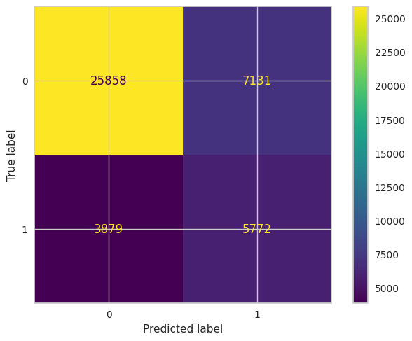

```python
from sklearn.metrics import ConfusionMatrixDisplay

dt_cm = confusion_matrix(y_test, dt_prediction)
ConfusionMatrixDisplay(dt_cm).plot()
```

### Get true positive rate from confusion matrix

```python
dt_tn, dt_fp, dt_fn, dt_tp = dt_cm.ravel()
dt_confusion_matrix = np.array([[dt_tp, dt_fp], [dt_fn, dt_tn]])
dt_true_positive_rate = dt_tp / (dt_tp + dt_fn)
print(dt_true_positive_rate)
print(dt_confusion_matrix)
```

```
0.5980727385763134
[[ 5772  7131]
 [ 3879 25858]]
```

### ROC curve

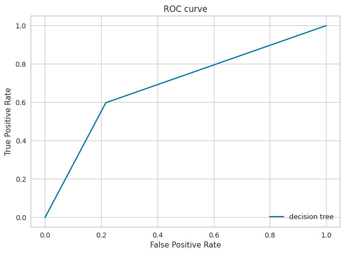

```python
from sklearn.metrics import RocCurveDisplay

dt_fpr, dt_tpr, thresholds  = roc_curve(y_test, dt_pred_proba, pos_label=dt_clf.classes_[1])
roc_display = RocCurveDisplay(fpr=dt_fpr, tpr=dt_tpr,estimator_name="decision tree").plot()
plt.title("ROC curve")
```

Because of the binary probabilities, the curve looks linear

### AUC score

Calculating area under the ROC curve

```python
from sklearn.metrics import roc_auc_score

dt_auc = roc_auc_score(y_test, dt_pred_proba)
print(dt_auc)
```

```
0.6909548875821335
```

### Cost of misscalculations - with different thresholds

Assigning imaginary costs

```python
assigned_costs = [0, 50, 100, 0] #[tp, fp, fn, tn]

#Generating thresholds from interval 0-1
thresholds = np.linspace(0, 1, 11)
```

Counting total costs

```python
dt_costs = []
for threshold in thresholds:
    tp = np.sum((dt_pred_proba >= threshold) & (y_test == 1))
    fp = np.sum((dt_pred_proba >= threshold) & (y_test == 0))
    fn = np.sum((dt_pred_proba < threshold) & (y_test == 1))
    tn = np.sum((dt_pred_proba < threshold) & (y_test == 0))
    total_cost = (tp * assigned_costs[0] + fp * assigned_costs[1] + fn * assigned_costs[2] + tn * assigned_costs[3]) / 1000
    dt_costs.append(total_cost)
```

Minimum cost

```python
import numpy as np

dt_min_cost = np.argmin(dt_costs)
print("Minimum cost (in thousands): " + str(dt_costs[dt_min_cost]))
```

```
Minimum cost (in thousands): 744.45
```

Costs dataframe

```python
dt_cost_df = pd.DataFrame({'Threshold': thresholds, 'Total cost (in thousands)': dt_costs})
print(dt_cost_df)
```

```
    Threshold  Total cost (in thousands)
0         0.0                    1649.45
1         0.1                     744.45
2         0.2                     744.45
3         0.3                     744.45
4         0.4                     744.45
5         0.5                     744.45
6         0.6                     744.45
7         0.7                     744.45
8         0.8                     744.45
9         0.9                     744.45
10        1.0                     744.45
```

Cost shown in chart

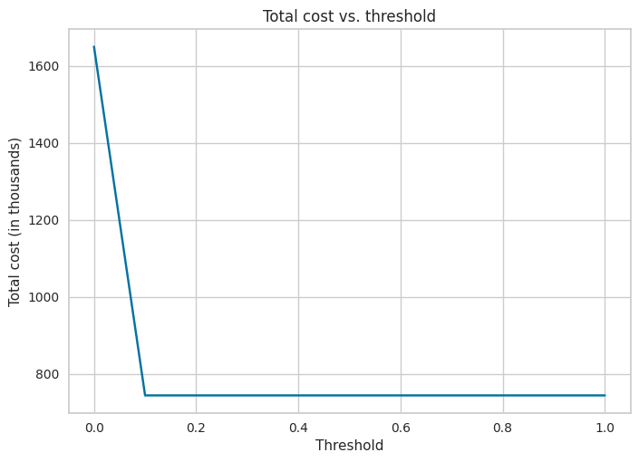

```python
plt.plot(thresholds, dt_costs)
plt.title("Total cost vs. threshold")
plt.xlabel("Threshold")
plt.ylabel("Total cost (in thousands)")
plt.grid(True)
plt.show()
```

```python
import bctools as bc
threshold_step = 0.125
optimize_threshold = 'all'
train_cost_dict = bc.get_cost_dict(TN = 0, FP = 50, FN = 100, TP = 0)
```

```python
bc.confusion_matrix_plot
```

```
<function bctools.plots.confusion_matrix_plot(true_y, predicted_proba, threshold_step=0.01, amounts=None, cost_dict=None, currency='€', title='Interactive Confusion Matrix')>
```

```python
cf_fig, var_metrics_df, invar_metrics_df, opt_thresh_df = bc.confusion_matrix_plot(
    true_y = y_test,
    predicted_proba = dt_pred_proba,
    threshold_step = threshold_step,
    cost_dict = train_cost_dict,
    currency = currency,
    title = 'Interactive Confusion Matrix with costs for decision tree model')
cf_fig
```

[interactive chart not shown]

The total cost for the decision tree model are the lowest for the threshold from around 0,125 and higher.

## Alternative decision tree model

### Get accuracy

```python
dt2_accuracy = accuracy_score(y_test, dt2_prediction)
print(round(dt2_accuracy, 3))
```

```
0.72
```

### F1 score

```python
dt2_f1 = f1_score(y_test, dt2_prediction)
print(dt2_f1)
```

```
0.5690769286307354
```

### Get other important metrics

Show with classification report

```python
dt2_report = classification_report(y_test, dt2_prediction)
print(dt2_report)
```

```
              precision    recall  f1-score   support

         0.0       0.93      0.69      0.79     32989
         1.0       0.44      0.82      0.57      9651

    accuracy                           0.72     42640
   macro avg       0.68      0.75      0.68     42640
weighted avg       0.82      0.72      0.74     42640
```

### Confusion matrix

Visualize number of tp, fp, fn, tn instances in matrix

```
<sklearn.metrics._plot.confusion_matrix.ConfusionMatrixDisplay at 0x7f5ede68bf10>
```

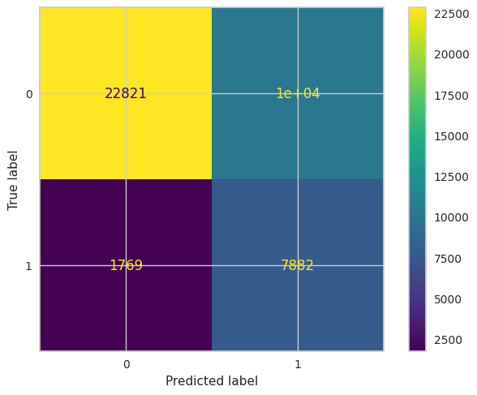

```python
dt2_cm = confusion_matrix(y_test, dt2_prediction)
ConfusionMatrixDisplay(dt2_cm).plot()
```

### True positive rate from confusion matrix

```python
dt2_tn, dt2_fp, dt2_fn, dt2_tp = dt2_cm.ravel()
dt2_confusion_matrix = np.array([[dt2_tp, dt2_fp], [dt2_fn, dt2_tn]])
dt2_true_positive_rate = dt2_tp / (dt2_tp + dt2_fn)
print(dt2_true_positive_rate)
print(dt2_confusion_matrix)
```

```
0.8167029323386178
[[ 7882 10168]
 [ 1769 22821]]
```

### ROC curve

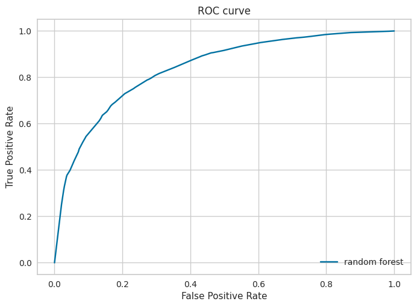

```python
dt2_fpr, dt2_tpr, thresholds  = roc_curve(y_test, dt2_pred_proba, pos_label=dt_clf2.classes_[1])
roc_display = RocCurveDisplay(fpr=dt2_fpr, tpr=dt2_tpr,estimator_name="random forest").plot()
plt.title("ROC curve")
```

ROC curve is now much less linear in comparison to decision tree with unlimited depth

### AUC score

Area under the ROC curve

```python
dt2_auc = roc_auc_score(y_test, dt2_pred_proba)
print(dt2_auc)
```

```
0.8384021191315365
```

### Cost of misscalculations - with various thresholds

Counting total cost

```python
dt2_costs = []
for threshold in thresholds:
    tp = np.sum((dt2_pred_proba >= threshold) & (y_test == 1))
    fp = np.sum((dt2_pred_proba >= threshold) & (y_test == 0))
    fn = np.sum((dt2_pred_proba < threshold) & (y_test == 1))
    tn = np.sum((dt2_pred_proba < threshold) & (y_test == 0))
    total_cost = (tp * assigned_costs[0] + fp * assigned_costs[1] + fn * assigned_costs[2] + tn * assigned_costs[3]) / 1000
    dt2_costs.append(total_cost)
```

Minimum cost

```python
dt2_min_cost = np.argmin(dt2_costs)
print("Minimum cost (in thousands): " + str(dt2_costs[dt2_min_cost]))
```

```
Minimum cost (in thousands): 583.85
```

Costs dataframe

```python
dt2_cost_df = pd.DataFrame({'Threshold': thresholds, 'Total cost (in thousands)': dt2_costs})
print(dt2_cost_df)
```

```
    Threshold  Total cost (in thousands)
0         inf                     965.10
1    0.969436                     756.15
2    0.956154                     708.95
3    0.951576                     694.75
4    0.944472                     665.30
5    0.940618                     660.90
6    0.884152                     655.45
7    0.877617                     635.60
8    0.866375                     619.30
9    0.857704                     611.35
10   0.848446                     600.05
11   0.848272                     593.95
12   0.824934                     592.25
13   0.814766                     591.15
```

[output cut: 45 more lines]

Costs shown in chart

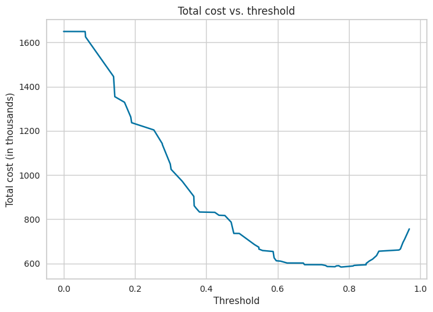

```python
plt.plot(thresholds, dt2_costs)
plt.title("Total cost vs. threshold")
plt.xlabel("Threshold")
plt.ylabel("Total cost (in thousands)")
plt.grid(True)
plt.show()
```

```python
cf_fig, var_metrics_df, invar_metrics_df, opt_thresh_df = bc.confusion_matrix_plot(
    true_y = y_test,
    predicted_proba = dt2_pred_proba,
    threshold_step = threshold_step,
    cost_dict = train_cost_dict,
    currency = currency,
    title = 'Interactive Confusion Matrix with costs for alternative decision tree model')
cf_fig
```

[interactive chart not shown]

The total cost for the alternative decision tree model are the lowest for the threshold of around 0.75.

## Random forest

### Get accuracy

```python
rf_accuracy = accuracy_score(y_test, rf_prediction)
print(round(rf_accuracy, 3))
```

```
0.821
```

### F1 score

```python
rf_f1 = f1_score(y_test, rf_prediction)
print(rf_f1)
```

```
0.6376207615078613
```

### Get other important metrics

Classification report

```python
rf_report = classification_report(y_test, rf_prediction)
print(rf_report)
```

```
              precision    recall  f1-score   support

         0.0       0.91      0.86      0.88     32989
         1.0       0.59      0.70      0.64      9651

    accuracy                           0.82     42640
   macro avg       0.75      0.78      0.76     42640
weighted avg       0.83      0.82      0.83     42640
```

### Confusion matrix

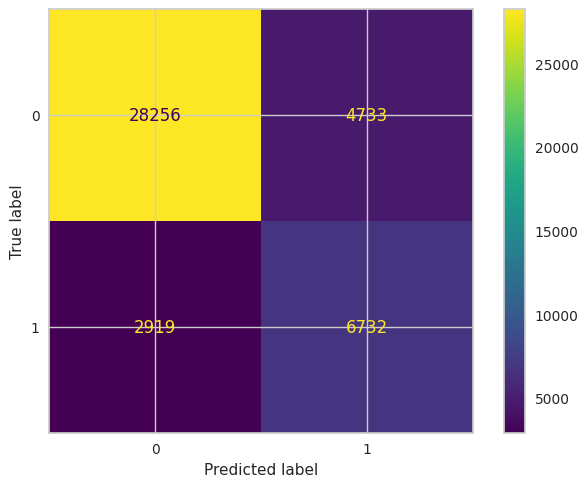

```python
rf_cm = confusion_matrix(y_test, rf_prediction)
rf_cm_display = ConfusionMatrixDisplay(rf_cm).plot()
```

### True positive rate from confusion matrix

```python
rf_tn, rf_fp, rf_fn, rf_tp = rf_cm.ravel()
rf_confusion_matrix = np.array([[rf_tp, rf_fp], [rf_fn, rf_tn]])
true_positive_rate = rf_tp / (rf_tp + rf_fn)
print(true_positive_rate)
print(rf_confusion_matrix)
```

```
0.6975442959278831
[[ 6732  4733]
 [ 2919 28256]]
```

### Predicted true instances based on threshold

```python
#All values
threshold = 0

preds = pd.Series(rf_pred_proba >= threshold)
print(sum(preds))
```

```
42640
```

```python
threshold = 0.3

preds = pd.Series(rf_pred_proba >= threshold)
print(sum(preds))
```

```
20237
```

```python
threshold = 0.5

preds = pd.Series(rf_pred_proba >= threshold)
print(sum(preds))
```

```
11791
```

```python
threshold = 0.7

preds = pd.Series(rf_pred_proba >= threshold)
print(sum(preds))
```

```
6459
```

```python
threshold = 0.9

preds = pd.Series(rf_pred_proba >= threshold)
print(sum(preds))
```

```
1862
```

```python
threshold = 1

preds = pd.Series(rf_pred_proba >= threshold)
print(sum(preds))
```

```
30
```

### ROC curve

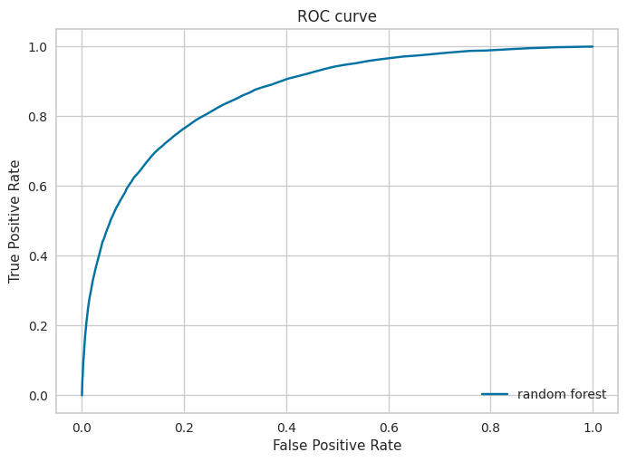

```python
from sklearn.metrics import RocCurveDisplay

rf_fpr, rf_tpr, thresholds  = roc_curve(y_test, rf_pred_proba, pos_label=rf_clf.classes_[1])
roc_display = RocCurveDisplay(fpr=rf_fpr, tpr=rf_tpr,estimator_name="random forest").plot()
plt.title("ROC curve")
```

### AUC score

Area under ROC curve

```python
from sklearn.metrics import roc_auc_score

rf_auc=roc_auc_score(y_test, rf_pred_proba)
print(rf_auc)
```

```
0.8666864457436239
```

### Costs of misclassifications - with various thresholds

Counting total cost

```python
rf_costs = []
for threshold in thresholds:
    tp = np.sum((rf_pred_proba >= threshold) & (y_test == 1))
    fp = np.sum((rf_pred_proba >= threshold) & (y_test == 0))
    fn = np.sum((rf_pred_proba < threshold) & (y_test == 1))
    tn = np.sum((rf_pred_proba < threshold) & (y_test == 0))
    total_cost = (tp * assigned_costs[0] + fp * assigned_costs[1] + fn * assigned_costs[2] + tn * assigned_costs[3]) / 1000
    rf_costs.append(total_cost)
```

Minimal cost

```python
rf_min_cost = np.argmin(rf_costs)
print("Minimum cost (in thousands): " + str(rf_costs[rf_min_cost]))
```

```
Minimum cost (in thousands): 527.7
```

Costs dataframe

```python
rf_cost_df = pd.DataFrame({'Threshold': thresholds, 'Total cost (in thousands)': rf_costs})
print(rf_cost_df)
```

```
     Threshold  Total cost (in thousands)
0          inf                     965.10
1         1.00                     962.25
2         0.99                     955.45
3         0.98                     944.00
4         0.97                     930.70
..         ...                        ...
97        0.04                    1570.05
98        0.03                    1601.10
99        0.02                    1625.05
100       0.01                    1642.85
101       0.00                    1649.45

[102 rows x 2 columns]
```

Costs in chart

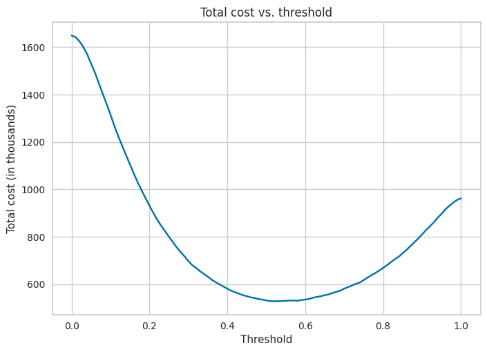

```python
plt.plot(thresholds, rf_costs)
plt.title("Total cost vs. threshold")
plt.xlabel("Threshold")
plt.ylabel("Total cost (in thousands)")
plt.grid(True)
plt.show()
```

```python
cf_fig, var_metrics_df, invar_metrics_df, opt_thresh_df = bc.confusion_matrix_plot(
    true_y = y_test,
    predicted_proba = rf_pred_proba,
    threshold_step = threshold_step,
    cost_dict = train_cost_dict,
    currency = currency,
    title = 'Interactive Confusion Matrix with costs for random forrest model')
cf_fig
```

[interactive chart not shown]

Lowest total cost are for threshold of 0.5.

## Baseline classifiers

### DummyClassifier - uniform strategy

Accuracy

```python
dummy_rand_acc = accuracy_score(y_test, dummy_pred_rand)
print(dummy_rand_acc)
```

```
0.4974671669793621
```

ROC curve

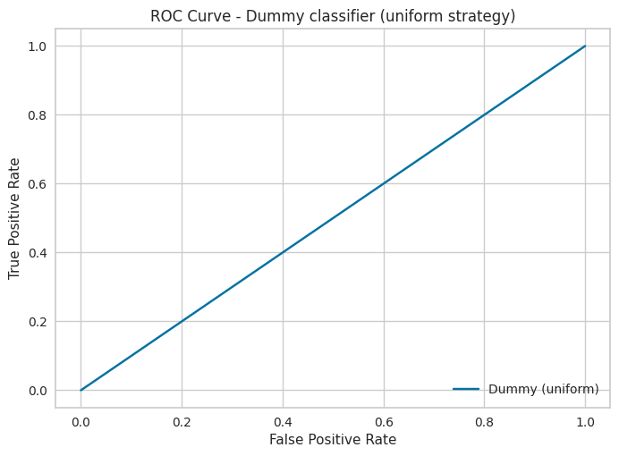

```python
fpr_dummy_rand, tpr_dummy_rand,thresholds_dummy_rand  = roc_curve(y_test, dummy_pred_rand_proba, pos_label = dummy_clf_uniform.classes_[1])
roc_display = RocCurveDisplay(fpr = fpr_dummy_rand, tpr = tpr_dummy_rand, estimator_name="Dummy (uniform)").plot()

plt.title("ROC Curve - Dummy classifier (uniform strategy)")
```

AUC score

```python
dummy_rand_auc = roc_auc_score(y_test, dummy_pred_rand_proba)
print(dummy_rand_auc)
```

```
0.5
```

### Dummy classifier - most frequent class strategy

Accuracy

```python
dummy_mfc_acc = accuracy_score(y_test, dummy_pred_mfc)
print(dummy_mfc_acc)
```

```
0.7736632270168855
```

ROC curve

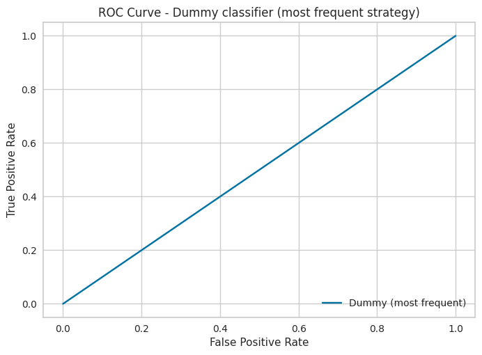

```python
fpr_mfc, tpr_mfc,_thresholds  = roc_curve(y_test, dummy_pred_mfc_proba, pos_label=dummy_clf_mfc.classes_[1])
roc_display = RocCurveDisplay(fpr=fpr_mfc, tpr=tpr_mfc, estimator_name="Dummy (most frequent)").plot()

plt.title("ROC Curve - Dummy classifier (most frequent strategy)")
```

AUC score

```python
dummy_mfc_auc = roc_auc_score(y_test, dummy_pred_mfc_proba)
print(dummy_mfc_auc)
```

```
0.5
```

## Comparison

### Comparing performance metrics

We will compare the accuracy scores:

```python
print(f"Decision tree: {round(dt_accuracy,3)*100}%")
print(f"Decision tree with tuned hyperparameters: {round(dt2_accuracy,3)*100}%")
print(f"Random forrest: {round(rf_accuracy,3)*100}%")
print(f"Dummy - unifrom: {round(dummy_rand_acc,3)*100}%")
print(f"Dummy - most frequent: {round(dummy_mfc_acc,3)*100}%")
```

```
Decision tree: 74.2%
Decision tree with tuned hyperparameters: 72.0%
Random forrest: 82.1%
Dummy - unifrom: 49.7%
Dummy - most frequent: 77.4%
```

We will compare F1 scores:

```python
print(f"Decision tree: {round(dt_f1,3)*100}%")
print(f"Decision tree with tuned hyperparameters: {round(dt2_f1,3)*100}%")
print(f"Random forrest: {round(rf_f1,3)*100}%")
```

```
Decision tree: 51.2%
Decision tree with tuned hyperparameters: 56.89999999999999%
Random forrest: 63.800000000000004%
```

```python
print(f"Decision tree:\n {dt_report}")
print(f"Decision tree with tuned hyperparameters:\n {dt2_report}")
print(f"Random forrest:\n {rf_report}")
```

```
Decision tree:
               precision    recall  f1-score   support

         0.0       0.87      0.78      0.82     32989
         1.0       0.45      0.60      0.51      9651

    accuracy                           0.74     42640
   macro avg       0.66      0.69      0.67     42640
weighted avg       0.77      0.74      0.75     42640

Decision tree with tuned hyperparameters:
               precision    recall  f1-score   support

         0.0       0.93      0.69      0.79     32989
         1.0       0.44      0.82      0.57      9651

    accuracy                           0.72     42640
   macro avg       0.68      0.75      0.68     42640
weighted avg       0.82      0.72      0.74     42640

Random forrest:
               precision    recall  f1-score   support

         0.0       0.91      0.86      0.88     32989
         1.0       0.59      0.70      0.64      9651

    accuracy                           0.82     42640
   macro avg       0.75      0.78      0.76     42640
weighted avg       0.83      0.82      0.83     42640
```

Based on both the accuracy and f1-scores the best performing model is the **random forrest**.

### Comparing ROC curves (and AUC scores)

[figure not shown]

```python
plt.figure(0).clf()
plt.plot(rf_fpr,rf_tpr,label="Random forest, auc="+str(round(rf_auc,2)))
plt.plot(dt_fpr, dt_tpr,label="Decision tree, auc="+str(round(dt_auc,2)))
plt.plot(dt2_fpr, dt2_tpr,label="Decision tree (tuned), auc="+str(round(dt2_auc,2)))
plt.plot(fpr_mfc,tpr_mfc, label="Dummy classifier (most frequent), auc="+str(dummy_mfc_acc))
plt.plot(fpr_dummy_rand,tpr_dummy_rand,linestyle='dotted',label="Dummy classifier (uniform), auc="+str(dummy_rand_acc))
plt.legend(loc=0)
plt.show()
```

### Cost analysis

```python
cost_matrix = np.array([[0, 50], [100, 0]])

dt_total_cost_matrix = np.multiply(dt_confusion_matrix, cost_matrix)
dt2_total_cost_matrix = np.multiply(dt2_confusion_matrix, cost_matrix)
rf_total_cost_matrix = np.multiply(rf_confusion_matrix, cost_matrix)

# Calculate the total cost
dt_total_cost = np.sum(dt_total_cost_matrix)
dt2_total_cost = np.sum(dt2_total_cost_matrix)
rf_total_cost = np.sum(rf_total_cost_matrix)

print("Total cost associated with the decision tree confusion matrix:", dt_total_cost)
print("Total cost associated with the tuned decision tree confusion matrix:", dt2_total_cost)
print("Total cost associated with the random forrest confusion matrix:", rf_total_cost)
```

```
Total cost associated with the decision tree confusion matrix: 744450
Total cost associated with the tuned decision tree confusion matrix: 685300
Total cost associated with the random forrest confusion matrix: 528550
```

The lowest costs were achieved with the **random forrest model**.

# 5) Explanation

### Global Explanation

Decision tree (tuned)

Displaying the decision tree graph:

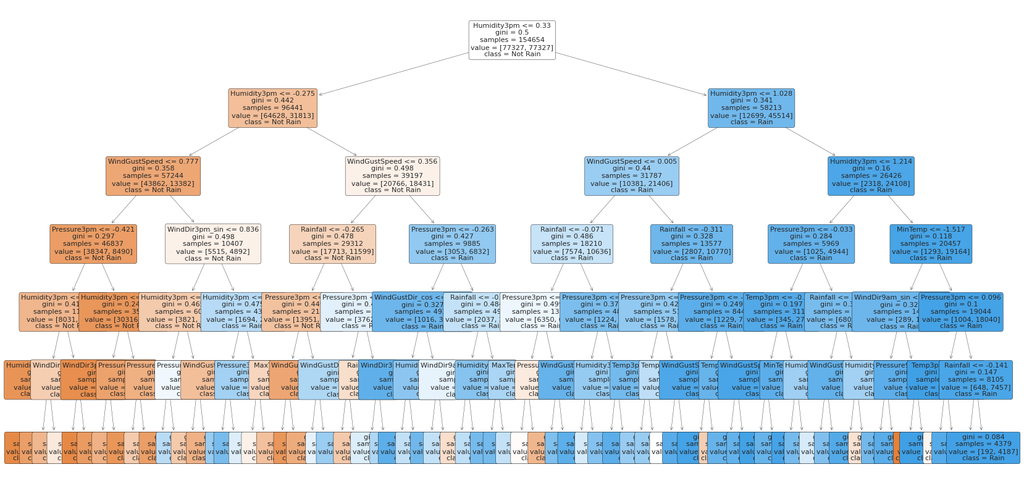

```python
plt.figure(figsize=(20,10))

plot_tree(dt_clf2,
          filled=True,
          feature_names=list(train_set_classification.columns),
          class_names=['Not Rain', 'Rain'],
          rounded=True,
          fontsize=8)

plt.show()
```

List the most important attributes:

```
[2.53241521e-03 6.97348458e-03 4.28647338e-02 1.25566868e-01
 0.00000000e+00 0.00000000e+00 2.50691969e-03 7.20706183e-01
 5.74922728e-04 7.06473219e-02 5.62464803e-04 3.88738237e-03
 0.00000000e+00 0.00000000e+00 7.68659849e-04 1.58723156e-03
 1.35518997e-03 1.45464809e-03 1.80115743e-02]
```

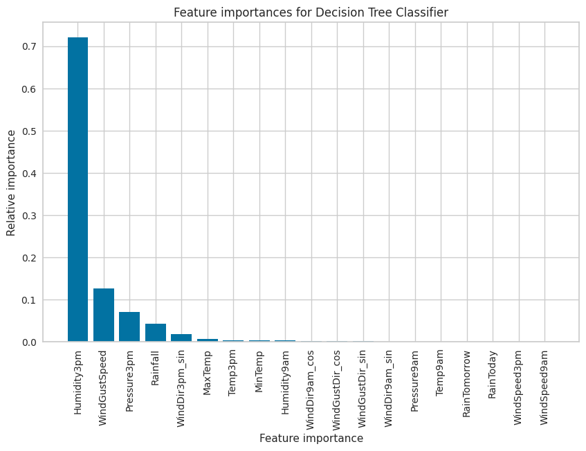

```python
importances = dt_clf2.feature_importances_
print(importances)
feature_names = train_set_classification.columns
sorted_indices = np.argsort(importances)[::-1]

sorted_feature_importances = importances[sorted_indices]
sorted_feature_names = feature_names[sorted_indices]


plt.figure(figsize=(10, 6))
plt.bar(range(X_train.shape[1]), sorted_feature_importances, align='center')
plt.xticks(range(X_train.shape[1]), sorted_feature_names, rotation=90)
plt.xlabel('Feature importance')
plt.ylabel('Relative importance')
plt.title('Feature importances for Decision Tree Classifier')
plt.show()
```

From both the decision tree visualization and the featrue importance graph it is obvious that the most important features are Humidity3pm and WindGustSpeed.

Random forrest

Showing the feature importance of variables in the forrest:

```
[0.05522588 0.05282997 0.06850443 0.06453224 0.03506447 0.03754102
 0.0690514  0.19727695 0.06509205 0.07158563 0.05155436 0.0569563
 0.02499545 0.02420307 0.02590144 0.02399845 0.0247033  0.02353911
 0.02744447]
```

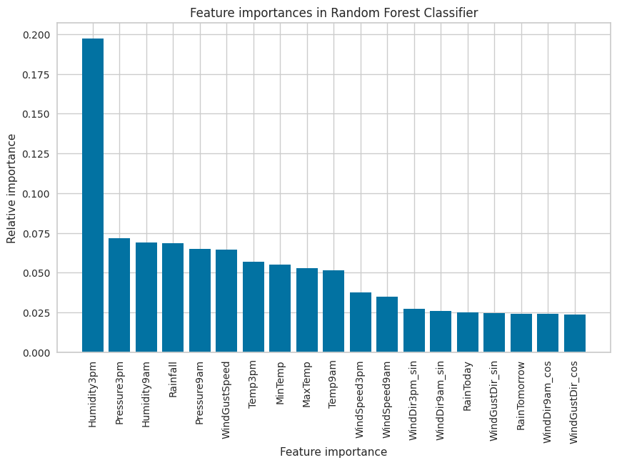

```python
importances = rf_clf.feature_importances_
print(importances)
feature_names = train_set_classification.columns
sorted_indices = np.argsort(importances)[::-1]

sorted_feature_importances = importances[sorted_indices]
sorted_feature_names = feature_names[sorted_indices]

plt.figure(figsize=(10, 6))
plt.bar(range(X_train.shape[1]), sorted_feature_importances, align='center')
plt.xticks(range(X_train.shape[1]), sorted_feature_names, rotation=90)
plt.xlabel('Feature importance')
plt.ylabel('Relative importance')
plt.title('Feature importances in Random Forest Classifier')
plt.show()
```

From the feature importance graph it is obvious that the most important features is Humidity3pm.

### Local explanation

Show the instance of interest:

```python
selected_instance
```

```
Date             2012-03-12
Location              Perth
MinTemp                15.8
MaxTemp                40.6
Rainfall                0.0
Evaporation             9.2
Sunshine               11.3
WindGustDir             WSW
WindGustSpeed          31.0
WindDir9am               NE
WindDir3pm              WSW
WindSpeed9am            9.0
WindSpeed3pm           13.0
Humidity9am            28.0
Humidity3pm            28.0
Pressure9am          1008.0
Pressure3pm          1005.1
Cloud9am                2.0
Cloud3pm                2.0
Temp9am                30.1
Temp3pm                33.9
RainToday                No
RainTomorrow             No
Name: 121958, dtype: object
```

We have to perform all the preprocessing steps for this instance:

```python
selected_instance_df = selected_instance.to_frame().transpose()
selected_instance_df
```

|  | Date | Location | MinTemp | MaxTemp | Rainfall | Evaporation | Sunshine | WindGustDir | WindGustSpeed | WindDir9am | ... | Humidity9am | Humidity3pm | Pressure9am | Pressure3pm | Cloud9am | Cloud3pm | Temp9am | Temp3pm | RainToday | RainTomorrow |
| --- | --- | --- | --- | --- | --- | --- | --- | --- | --- | --- | --- | --- | --- | --- | --- | --- | --- | --- | --- | --- | --- |
| 121958 | 2012-03-12 | Perth | 15.8 | 40.6 | 0.0 | 9.2 | 11.3 | WSW | 31.0 | NE | ... | 28.0 | 28.0 | 1008.0 | 1005.1 | 2.0 | 2.0 | 30.1 | 33.9 | No | No |

1 rows × 23 columns

```python
for col in ['WindDir9am', 'WindGustDir', 'WindDir3pm']:
    if col in selected_instance_df.columns:  # Check if the column exists
        selected_instance_df = convert_wind_direction(selected_instance_df, col)
```

```python
selected_instance_df = selected_instance_df.drop(['WindDir9am', 'WindGustDir', 'WindDir3pm', 'Sunshine', 'Evaporation', 'Cloud3pm', 'Cloud9am'], axis=1, errors='ignore')
```

```python
selected_instance_df['RainToday'] = selected_instance_df['RainToday'].map({'Yes': 1, 'No': 0})
selected_instance_df = selected_instance_df.drop(columns=['RainTomorrow', 'Date', 'Location'])


columns_to_exclude = ['RainTomorrow', 'RainToday']
numerical_columns = [col for col in train_set_classification.columns if col not in columns_to_exclude]
selected_instance_numerical = selected_instance_df[numerical_columns]
```

```python
selected_instance_scaled = scaler.transform(selected_instance_numerical)
selected_instance_df[numerical_columns] = selected_instance_scaled
```

```python
selected_instance_df
```

|  | MinTemp | MaxTemp | Rainfall | WindGustSpeed | WindSpeed9am | WindSpeed3pm | Humidity9am | Humidity3pm | Pressure9am | Pressure3pm | Temp9am | Temp3pm | RainToday | WindDir9am_sin | WindDir9am_cos | WindGustDir_sin | WindGustDir_cos | WindDir3pm_sin | WindDir3pm_cos |
| --- | --- | --- | --- | --- | --- | --- | --- | --- | --- | --- | --- | --- | --- | --- | --- | --- | --- | --- | --- |
| 121958 | 0.563931 | 2.442591 | -0.274622 | -0.682883 | -0.564242 | -0.651299 | -2.146787 | -1.139559 | -1.441667 | -1.531708 | 2.024161 | 1.778236 | 0 | 1.027355 | 0.844868 | -1.153314 | -0.501453 | -1.3048 | -0.453167 |

```python
dt_pred_class = dt_clf2.predict(selected_instance_df)
rf_pred_class = rf_clf.predict(selected_instance_df)

same_class = dt_pred_class == rf_pred_class

dt_pred_prob = dt_clf2.predict_proba(selected_instance_df)
rf_pred_prob = rf_clf.predict_proba(selected_instance_df)

print(f"Decision Tree predicted class: {dt_pred_class}")
print(f"Random Forest predicted class: {rf_pred_class}")
print(f"Do both models assign the same class? {'Yes' if same_class else 'No'}")
print(f"Decision Tree prediction confidence: {dt_pred_prob}")
print(f"Random Forest prediction confidence: {rf_pred_prob}")
```

```
Decision Tree predicted class: [0.]
Random Forest predicted class: [0.]
Do both models assign the same class? Yes
Decision Tree prediction confidence: [[0.69855305 0.30144695]]
Random Forest prediction confidence: [[0.85 0.15]]
```

Both the Decision Tree and Random Forest models predicted that the instance belongs to class [0], therefore it would not rain tomorrow.

Changing the value of the atribute of interest:

We will change the humidity to the extreme value of 100% to see if the models will change their prediction.

```python
modified_instance = selected_instance.copy()
modified_instance['Humidity3pm'] = 100
```

```python
modified_instance
```

```
Date             2012-03-12
Location              Perth
MinTemp                15.8
MaxTemp                40.6
Rainfall                0.0
Evaporation             9.2
Sunshine               11.3
WindGustDir             WSW
WindGustSpeed          31.0
WindDir9am               NE
WindDir3pm              WSW
WindSpeed9am            9.0
WindSpeed3pm           13.0
Humidity9am            28.0
Humidity3pm             100
Pressure9am          1008.0
Pressure3pm          1005.1
Cloud9am                2.0
Cloud3pm                2.0
Temp9am                30.1
Temp3pm                33.9
RainToday                No
RainTomorrow             No
Name: 121958, dtype: object
```

```python
modified_instance_df = modified_instance.to_frame().transpose()
modified_instance_df
```

|  | Date | Location | MinTemp | MaxTemp | Rainfall | Evaporation | Sunshine | WindGustDir | WindGustSpeed | WindDir9am | ... | Humidity9am | Humidity3pm | Pressure9am | Pressure3pm | Cloud9am | Cloud3pm | Temp9am | Temp3pm | RainToday | RainTomorrow |
| --- | --- | --- | --- | --- | --- | --- | --- | --- | --- | --- | --- | --- | --- | --- | --- | --- | --- | --- | --- | --- | --- |
| 121958 | 2012-03-12 | Perth | 15.8 | 40.6 | 0.0 | 9.2 | 11.3 | WSW | 31.0 | NE | ... | 28.0 | 100 | 1008.0 | 1005.1 | 2.0 | 2.0 | 30.1 | 33.9 | No | No |

1 rows × 23 columns

```python
for col in ['WindDir9am', 'WindGustDir', 'WindDir3pm']:
    if col in modified_instance_df.columns:  # Check if the column exists
        modified_instance_df = convert_wind_direction(modified_instance_df, col)
modified_instance_df = modified_instance_df.drop(['WindDir9am', 'WindGustDir', 'WindDir3pm', 'Sunshine', 'Evaporation', 'Cloud3pm', 'Cloud9am'], axis=1, errors='ignore')
modified_instance_df['RainToday'] = modified_instance_df['RainToday'].map({'Yes': 1, 'No': 0})
modified_instance_df = modified_instance_df.drop(columns=['RainTomorrow', 'Date', 'Location'])


columns_to_exclude = ['RainTomorrow', 'RainToday']
numerical_columns = [col for col in train_set_classification.columns if col not in columns_to_exclude]
modified_instance_numerical = modified_instance_df[numerical_columns]

modified_instance_scaled = scaler.transform(modified_instance_numerical)
modified_instance_df[numerical_columns] = modified_instance_scaled
```

```python
modified_instance_df
```

|  | MinTemp | MaxTemp | Rainfall | WindGustSpeed | WindSpeed9am | WindSpeed3pm | Humidity9am | Humidity3pm | Pressure9am | Pressure3pm | Temp9am | Temp3pm | RainToday | WindDir9am_sin | WindDir9am_cos | WindGustDir_sin | WindGustDir_cos | WindDir3pm_sin | WindDir3pm_cos |
| --- | --- | --- | --- | --- | --- | --- | --- | --- | --- | --- | --- | --- | --- | --- | --- | --- | --- | --- | --- |
| 121958 | 0.563931 | 2.442591 | -0.274622 | -0.682883 | -0.564242 | -0.651299 | -2.146787 | 2.351925 | -1.441667 | -1.531708 | 2.024161 | 1.778236 | 0 | 1.027355 | 0.844868 | -1.153314 | -0.501453 | -1.3048 | -0.453167 |

```python
dt_pred_class = dt_clf2.predict(modified_instance_df)
rf_pred_class = rf_clf.predict(modified_instance_df)

same_class = dt_pred_class == rf_pred_class

dt_pred_prob = dt_clf2.predict_proba(modified_instance_df)
rf_pred_prob = rf_clf.predict_proba(modified_instance_df)

print(f"Decision Tree predicted class: {dt_pred_class}")
print(f"Random Forest predicted class: {rf_pred_class}")
print(f"Do both models assign the same class? {'Yes' if same_class else 'No'}")
print(f"Decision Tree prediction confidence: {dt_pred_prob}")
print(f"Random Forest prediction confidence: {rf_pred_prob}")
```

```
Decision Tree predicted class: [0.]
Random Forest predicted class: [0.]
Do both models assign the same class? Yes
Decision Tree prediction confidence: [[0.52272727 0.47727273]]
Random Forest prediction confidence: [[0.67 0.33]]
```

The prediction will not change as the selected instance appears to be a very dry day. Other significant attributes would have to be changed to to classify the instance as class [1]. Both of the models have predicted the same class.

# Conclusion

In this data analysis project, we wanted to predict whether it would rain tomorrow by using classification models. The results were as follows:

The best result was yielded by using the default parameters of the Random Forest classifier. This reinforces the strength of Random Forest's built-in robustness to overfitting and its ability to work well with default settings for a variety of problems.

The most critical features influencing the prediction were humidity, pressure, and wind gust speed, aligning with common meteorological indicators for rain prediction. These attributes carry significant weight in weather forecasting and their prominence in the model underscores their real-world relevance.

Overall, the machine learning task provided a predictive model that could be used if not for rain prediction, then atleast for valuavle insights into what attributes influence rain prediction the most.

[figure not shown]

Created in Deepnote